# Overview

1. Project Instructions & Prerequisites
2. Learning Objectives
3. Data Preparation
4. Create Categorical Features with TF Feature Columns
5. Create Continuous/Numerical Features with TF Feature Columns
6. Build Deep Learning Regression Model with Sequential API and TF Probability Layers
7. Evaluating Potential Model Biases with Aequitas Toolkit

# 1. Project Instructions & Prerequisites

## Project Instructions

**Context**: You are a data scientist for an exciting unicorn healthcare startup that has created a groundbreaking diabetes drug that is ready for clinical trial testing. It is a very unique and sensitive drug that requires administering the drug over at least 5-7 days of time in the hospital with frequent monitoring/testing and patient medication adherence training with a mobile application. You have been provided a patient dataset from a client partner and are tasked with building a predictive model that can identify which type of patients the company should focus their efforts testing this drug on. Target patients are people that are likely to be in the hospital for this duration of time and will not incur significant additional costs for administering this drug to the patient and monitoring.

In order to achieve your goal you must build a regression model that can predict the estimated hospitalization time for a patient and use this to select/filter patients for your study.

**Expected Hospitalization Time Regression Model:** Utilizing a synthetic dataset(denormalized at the line level augmentation) built off of the UCI Diabetes readmission dataset, students will build a regression model that predicts the expected days of hospitalization time and then convert this to a binary prediction of whether to include or exclude that patient from the clinical trial.

This project will demonstrate the importance of building the right data representation at the encounter level, with appropriate filtering and preprocessing/feature engineering of key medical code sets. This project will also require students to analyze and interpret their model for biases across key demographic groups.

Please see the project rubric online for more details on the areas your project will be evaluated.

### Dataset

Due to healthcare PHI regulations (HIPAA, HITECH), there are limited number of publicly available datasets and some datasets require training and approval. So, for the purpose of this exercise, we are using a dataset from UC Irvine(https://archive.ics.uci.edu/ml/datasets/Diabetes+130-US+hospitals+for+years+1999-2008) that has been modified for this course. Please note that it is limited in its representation of some key features such as diagnosis codes which are usually an unordered list in 835s/837s (the HL7 standard interchange formats used for claims and remits).

**Data Schema** The dataset reference information can be found at https://github.com/udacity/nd320-c1-emr-data-starter/tree/master/project/data_schema_references and there are two CSVs that provide more details on the fields and some of the mapped values.

## Project Submission

When submitting this project, make sure to run all the cells before saving the notebook. Save the notebook file as "student_project_submission.ipynb" and save another copy as an HTML file by clicking "File" -> "Download as.."->"html". Include the "utils.py" and "student_utils.py" files in your submission. The student_utils.py should be where you put most of your code that you write and the summary and text explanations should be written inline in the notebook. Once you download these files, compress them into one zip file for submission.

## Prerequisites

- Intermediate level knowledge of Python
- Basic knowledge of probability and statistics
- Basic knowledge of machine learning concepts
- Installation of Tensorflow 2.0 and other dependencies(conda environment.yml or virtualenv requirements.txt file provided)

## Environment Setup

For step by step instructions on creating your environment, please go to https://github.com/udacity/nd320-c1-emr-data-starter/blob/master/README.md.

# 2. Learning Objectives

By the end of the project, you will be able to

- Use the Tensorflow Dataset API to scalably extract, transform, and load datasets and build datasets aggregated at the line, encounter, and patient data levels(longitudinal)
- Analyze EHR datasets to check for common issues (data leakage, statistical properties, missing values, high cardinality) by performing exploratory data analysis.
- Create categorical features from Key Industry Code Sets (ICD, CPT, NDC) and reduce dimensionality for high cardinality features by using embeddings
- Create derived features(bucketing, cross-features, embeddings) utilizing Tensorflow feature columns on both continuous and categorical input features
- SWBAT use the Tensorflow Probability library to train a model that provides uncertainty range predictions that allow for risk adjustment/prioritization and triaging of predictions
- Analyze and determine biases for a model for key demographic groups by evaluating performance metrics across groups by using the Aequitas framework

# 3. Data Preparation

```python
# from __future__ import absolute_import, division, print_function, unicode_literals
import os
import numpy as np
import tensorflow as tf
from tensorflow.keras import layers
import tensorflow_probability as tfp
import matplotlib.pyplot as plt
import pandas as pd
import aequitas as ae
# Put all of the helper functions in utils
from utils import build_vocab_files, show_group_stats_viz, aggregate_dataset, preprocess_df, df_to_dataset, posterior_mean_field, prior_trainable
pd.set_option('display.max_columns', 500)
# this allows you to make changes and save in student_utils.py and the file is reloaded every time you run a code block
%load_ext autoreload
%autoreload
```

## Dataset Loading and Schema Review

Load the dataset and view a sample of the dataset along with reviewing the schema reference files to gain a deeper understanding of the dataset. The dataset is located at the following path https://github.com/udacity/nd320-c1-emr-data-starter/blob/master/project/starter_code/data/final_project_dataset.csv. Also, review the information found in the data schema https://github.com/udacity/nd320-c1-emr-data-starter/tree/master/project/data_schema_references/.

```python
dataset_path = "./data/final_project_dataset.csv"
df = pd.read_csv(dataset_path)
```

```python
df
```

|  | encounter_id | patient_nbr | race | gender | age | weight | admission_type_id | discharge_disposition_id | admission_source_id | time_in_hospital | payer_code | medical_specialty | primary_diagnosis_code | other_diagnosis_codes | number_outpatient | number_inpatient | number_emergency | num_lab_procedures | number_diagnoses | num_medications | num_procedures | ndc_code | max_glu_serum | A1Cresult | change | readmitted |
| --- | --- | --- | --- | --- | --- | --- | --- | --- | --- | --- | --- | --- | --- | --- | --- | --- | --- | --- | --- | --- | --- | --- | --- | --- | --- | --- |
| 0 | 2278392 | 8222157 | Caucasian | Female | [0-10) | ? | 6 | 25 | 1 | 1 | ? | Pediatrics-Endocrinology | 250.83 | ?\|? | 0 | 0 | 0 | 41 | 1 | 1 | 0 | NaN | None | None | No | NO |
| 1 | 149190 | 55629189 | Caucasian | Female | [10-20) | ? | 1 | 1 | 7 | 3 | ? | ? | 276 | 250.01\|255 | 0 | 0 | 0 | 59 | 9 | 18 | 0 | 68071-1701 | None | None | Ch | >30 |
| 2 | 64410 | 86047875 | AfricanAmerican | Female | [20-30) | ? | 1 | 1 | 7 | 2 | ? | ? | 648 | 250\|V27 | 2 | 1 | 0 | 11 | 6 | 13 | 5 | 0378-1110 | None | None | No | NO |
| 3 | 500364 | 82442376 | Caucasian | Male | [30-40) | ? | 1 | 1 | 7 | 2 | ? | ? | 8 | 250.43\|403 | 0 | 0 | 0 | 44 | 7 | 16 | 1 | 68071-1701 | None | None | Ch | NO |
| 4 | 16680 | 42519267 | Caucasian | Male | [40-50) | ? | 1 | 1 | 7 | 1 | ? | ? | 197 | 157\|250 | 0 | 0 | 0 | 51 | 5 | 8 | 0 | 0049-4110 | None | None | Ch | NO |
| ... | ... | ... | ... | ... | ... | ... | ... | ... | ... | ... | ... | ... | ... | ... | ... | ... | ... | ... | ... | ... | ... | ... | ... | ... | ... | ... |
| 143419 | 443854148 | 41088789 | Caucasian | Male | [70-80) | ? | 1 | 1 | 7 | 1 | MC | ? | 38 | 590\|296 | 1 | 0 | 0 | 53 | 13 | 9 | 0 | 47918-902 | None | None | Ch | NO |
| 143420 | 443857166 | 31693671 | Caucasian | Female | [80-90) | ? | 2 | 3 | 7 | 10 | MC | Surgery-General | 996 | 285\|998 | 0 | 1 | 0 | 45 | 9 | 21 | 2 | 0049-4110 | None | None | Ch | NO |
| 143421 | 443857166 | 31693671 | Caucasian | Female | [80-90) | ? | 2 | 3 | 7 | 10 | MC | Surgery-General | 996 | 285\|998 | 0 | 1 | 0 | 45 | 9 | 21 | 2 | 0781-5421 | None | None | Ch | NO |
| 143422 | 443857166 | 31693671 | Caucasian | Female | [80-90) | ? | 2 | 3 | 7 | 10 | MC | Surgery-General | 996 | 285\|998 | 0 | 1 | 0 | 45 | 9 | 21 | 2 | 47918-902 | None | None | Ch | NO |
| 143423 | 443867222 | 175429310 | Caucasian | Male | [70-80) | ? | 1 | 1 | 7 | 6 | ? | ? | 530 | 530\|787 | 0 | 0 | 0 | 13 | 9 | 3 | 3 | NaN | None | None | No | NO |

143424 rows × 26 columns

```python
df.encounter_id.nunique()
```

```
101766
```

## Determine Level of Dataset (Line or Encounter)

**Question 1**: Based off of analysis of the data, what level is this dataset? Is it at the line or encounter level? Are there any key fields besides the encounter_id and patient_nbr fields that we should use to aggregate on? Knowing this information will help inform us what level of aggregation is necessary for future steps and is a step that is often overlooked.

The data is at line level. We have more rows than the number of unique encounters. Only `encounter_id` and `patient_nbr` are relevent columns for data aggregation.

## Analyze Dataset

**Question 2**: Utilizing the library of your choice (recommend Pandas and Seaborn or matplotlib though), perform exploratory data analysis on the dataset. In particular be sure to address the following questions:

```
- a. Field(s) with high amount of missing/zero values
- b. Based off the frequency histogram for each numerical field, which numerical field(s) has/have a Gaussian(normal) distribution shape?
- c. Which field(s) have high cardinality and why (HINT: ndc_code is one feature)
- d. Please describe the demographic distributions in the dataset for age and gender fields.
```

#### Q2.a Fields with high amount of missing or zero values

```python
def check_for_missing_and_null(df):
    null_df = pd.DataFrame({'columns':df.columns,
                         'percent_null':df.isnull().sum()*100/len(df),
                         'percent_Zero':df.isin([0]).sum()*100/len(df)})
    return null_df
```

```python
check_for_missing_and_null(df)
```

|  | columns | percent_null | percent_Zero |
| --- | --- | --- | --- |
| encounter_id | encounter_id | 0.00000 | 0.000000 |
| patient_nbr | patient_nbr | 0.00000 | 0.000000 |
| race | race | 0.00000 | 0.000000 |
| gender | gender | 0.00000 | 0.000000 |
| age | age | 0.00000 | 0.000000 |
| weight | weight | 0.00000 | 0.000000 |
| admission_type_id | admission_type_id | 0.00000 | 0.000000 |
| discharge_disposition_id | discharge_disposition_id | 0.00000 | 0.000000 |
| admission_source_id | admission_source_id | 0.00000 | 0.000000 |
| time_in_hospital | time_in_hospital | 0.00000 | 0.000000 |
| payer_code | payer_code | 0.00000 | 0.000000 |
| medical_specialty | medical_specialty | 0.00000 | 0.000000 |
| primary_diagnosis_code | primary_diagnosis_code | 0.00000 | 0.000000 |
| other_diagnosis_codes | other_diagnosis_codes | 0.00000 | 0.000000 |
| number_outpatient | number_outpatient | 0.00000 | 83.686831 |
| number_inpatient | number_inpatient | 0.00000 | 67.421073 |
| number_emergency | number_emergency | 0.00000 | 88.858211 |
| num_lab_procedures | num_lab_procedures | 0.00000 | 0.000000 |
| number_diagnoses | number_diagnoses | 0.00000 | 0.000000 |
| num_medications | num_medications | 0.00000 | 0.000000 |
| num_procedures | num_procedures | 0.00000 | 45.869589 |
| ndc_code | ndc_code | 16.35849 | 0.000000 |
| max_glu_serum | max_glu_serum | 0.00000 | 0.000000 |
| A1Cresult | A1Cresult | 0.00000 | 0.000000 |
| change | change | 0.00000 | 0.000000 |
| readmitted | readmitted | 0.00000 | 0.000000 |

```python
df.columns
```

```
Index(['encounter_id', 'patient_nbr', 'race', 'gender', 'age', 'weight',
       'admission_type_id', 'discharge_disposition_id', 'admission_source_id',
       'time_in_hospital', 'payer_code', 'medical_specialty',
       'primary_diagnosis_code', 'other_diagnosis_codes', 'number_outpatient',
       'number_inpatient', 'number_emergency', 'num_lab_procedures',
       'number_diagnoses', 'num_medications', 'num_procedures', 'ndc_code',
       'max_glu_serum', 'A1Cresult', 'change', 'readmitted'],
      dtype='object')
```

```python
df.race.value_counts()
```

```
Caucasian          107688
AfricanAmerican     26427
?                    3309
Hispanic             2938
Other                2174
Asian                 888
Name: race, dtype: int64
```

```python
df.gender.value_counts()
```

```
Female             76185
Male               67234
Unknown/Invalid        5
Name: gender, dtype: int64
```

```python
df.age.value_counts()
```

```
[70-80)     36928
[60-70)     32741
[50-60)     25095
[80-90)     23527
[40-50)     13729
[30-40)      4964
[90-100)     3619
[20-30)      1927
[10-20)       733
[0-10)        161
Name: age, dtype: int64
```

```python
df.weight.value_counts()
```

```
?            139122
[75-100)       1817
[50-75)        1133
[100-125)       890
[125-150)       200
[25-50)         118
[0-25)           67
[150-175)        55
[175-200)        18
>200              4
Name: weight, dtype: int64
```

```python
df.admission_type_id.value_counts()
```

```
1    74713
3    27756
2    26823
6     7015
5     6584
8      488
7       33
4       12
Name: admission_type_id, dtype: int64
```

```python
df.discharge_disposition_id.value_counts()
```

```
1     85308
3     19677
6     18945
18     4658
22     3077
2      2906
11     1911
5      1631
25     1285
4      1090
7       782
23      602
13      521
14      432
28      200
8       147
15       93
24       65
9        29
17       20
16       19
19        8
10        6
27        5
20        4
12        3
Name: discharge_disposition_id, dtype: int64
```

```python
df.admission_source_id.value_counts()
```

```
7     80443
1     42773
17     9338
4      4467
6      3108
2      1500
5      1048
20      247
3       247
9       185
8        27
22       21
10       10
25        4
11        3
14        2
13        1
Name: admission_source_id, dtype: int64
```

```python
df.time_in_hospital.value_counts()
```

```
3     24986
2     23475
4     20064
1     18530
5     14452
6     10880
7      8569
8      6464
9      4432
10     3416
11     2707
12     2116
13     1807
14     1526
Name: time_in_hospital, dtype: int64
```

```python
df.payer_code.value_counts()
```

```
?     54190
MC    46532
HM     8784
SP     7613
BC     6991
MD     4983
CP     3687
UN     3665
CM     2971
OG     1532
PO      919
DM      757
WC      230
CH      208
OT      160
MP      122
SI       79
FR        1
Name: payer_code, dtype: int64
```

```python
df.medical_specialty.value_counts()
```

```
?                                   69463
InternalMedicine                    20403
Emergency/Trauma                    11595
Family/GeneralPractice              10508
Cardiology                           7473
                                    ...
Surgery-PlasticwithinHeadandNeck        1
SportsMedicine                          1
Perinatology                            1
Proctology                              1
Speech                                  1
Name: medical_specialty, Length: 73, dtype: int64
```

```python
df.primary_diagnosis_code.value_counts()
```

```
414    9473
428    9385
786    5432
486    5226
410    5076
       ...
133       1
477       1
698       1
61        1
640       1
Name: primary_diagnosis_code, Length: 717, dtype: int64
```

```python
df.other_diagnosis_codes.value_counts()
```

```
250|401    3637
401|250    3060
276|276     968
414|250     922
428|427     911
           ...
710|403       1
496|620       1
486|?         1
799|791       1
642|493       1
Name: other_diagnosis_codes, Length: 19374, dtype: int64
```

```python
df.number_outpatient.value_counts()
```

```
0     120027
1      11976
2       5128
3       2808
4       1501
5        749
6        415
7        203
8        133
9        108
10        79
11        55
13        40
14        40
12        34
```

[output cut: 25 more lines]

```python
df.number_inpatient.value_counts()
```

```
0     96698
1     27427
2     10194
3      4472
4      2120
5      1031
6       597
7       334
8       179
9       141
10       80
11       57
12       38
13       22
14       14
15        9
16        6
19        2
17        1
18        1
21        1
Name: number_inpatient, dtype: int64
```

```python
df.number_emergency.value_counts()
```

```
0     127444
1      10897
2       2867
3        964
4        491
5        252
6        129
7         88
8         59
9         48
10        46
11        40
13        16
18        14
12        12
```

[output cut: 19 more lines]

```python
df.num_lab_procedures.value_counts()
```

```
1      4656
43     4011
44     3608
45     3387
38     3175
       ...
132       1
107       1
121       1
129       1
126       1
Name: num_lab_procedures, Length: 118, dtype: int64
```

```python
df.number_diagnoses.value_counts()
```

```
9     69427
5     16215
8     15296
7     14724
6     14170
4      7891
3      3916
2      1369
1       259
16       63
10       22
13       21
11       17
15       15
12       10
14        9
Name: number_diagnoses, dtype: int64
```

```python
df.num_medications.value_counts()
```

```
13    8399
15    8315
12    8227
14    8069
16    7888
      ...
72       6
70       4
79       3
74       3
81       2
Name: num_medications, Length: 75, dtype: int64
```

```python
df.num_procedures.value_counts()
```

```
0    65788
1    29039
2    17788
3    13252
6     7277
4     5951
5     4329
Name: num_procedures, dtype: int64
```

```python
df.ndc_code.value_counts()
```

```
68071-1701    20770
47918-902     20379
47918-898      6568
0173-0861      4060
50090-0353     4040
              ...
0228-2752         1
64764-302         1
0781-5635         1
43063-699         1
33342-177         1
Name: ndc_code, Length: 251, dtype: int64
```

```python
df.max_glu_serum.value_counts()
```

```
None    136409
Norm      3220
>200      2043
>300      1752
Name: max_glu_serum, dtype: int64
```

```python
df.A1Cresult.value_counts()
```

```
None    117650
>8       13110
Norm      6955
>7        5709
Name: A1Cresult, dtype: int64
```

```python
df.change.value_counts()
```

```
Ch    88669
No    54755
Name: change, dtype: int64
```

```python
df.readmitted.value_counts()
```

```
NO     77248
>30    50434
<30    15742
Name: readmitted, dtype: int64
```

Most missing values are designated with '?'. So we are going to transform that to np.nan values

```python
nanFilter = lambda x : np.nan if (x == '?') else x
```

```python
df.payer_code.map(nanFilter)
```

```
0         NaN
1         NaN
2         NaN
3         NaN
4         NaN
         ...
143419     MC
143420     MC
143421     MC
143422     MC
143423    NaN
Name: payer_code, Length: 143424, dtype: object
```

```python
df.payer_code
```

```
0          ?
1          ?
2          ?
3          ?
4          ?
          ..
143419    MC
143420    MC
143421    MC
143422    MC
143423     ?
Name: payer_code, Length: 143424, dtype: object
```

```python
# Apply the filter to all columns

for col in df.columns:
    df[col] = df[col].apply(nanFilter)
```

```python
df.payer_code
```

```
0         NaN
1         NaN
2         NaN
3         NaN
4         NaN
         ...
143419     MC
143420     MC
143421     MC
143422     MC
143423    NaN
Name: payer_code, Length: 143424, dtype: object
```

```python
df.isna().mean()
```

```
encounter_id                0.000000
patient_nbr                 0.000000
race                        0.023071
gender                      0.000000
age                         0.000000
weight                      0.970005
admission_type_id           0.000000
discharge_disposition_id    0.000000
admission_source_id         0.000000
time_in_hospital            0.000000
payer_code                  0.377831
medical_specialty           0.484319
primary_diagnosis_code      0.000230
other_diagnosis_codes       0.000000
number_outpatient           0.000000
number_inpatient            0.000000
number_emergency            0.000000
num_lab_procedures          0.000000
number_diagnoses            0.000000
num_medications             0.000000
num_procedures              0.000000
ndc_code                    0.163585
max_glu_serum               0.000000
A1Cresult                   0.000000
change                      0.000000
readmitted                  0.000000
dtype: float64
```

#### Removing columns with high percentage of na values, namely payer_code and medical_specialty.

Only 'weight', 'payer_code', 'medical_specialty'columns have high percentage of na values and are therefore dropped.

```python
df = df.drop(['weight', 'payer_code', 'medical_specialty'], axis = 1)
```

#### Removig pacients that have missing data

```python
df[df.isna().mean(axis = 1)>0]
```

|  | encounter_id | patient_nbr | race | gender | age | admission_type_id | discharge_disposition_id | admission_source_id | time_in_hospital | primary_diagnosis_code | other_diagnosis_codes | number_outpatient | number_inpatient | number_emergency | num_lab_procedures | number_diagnoses | num_medications | num_procedures | ndc_code | max_glu_serum | A1Cresult | change | readmitted |
| --- | --- | --- | --- | --- | --- | --- | --- | --- | --- | --- | --- | --- | --- | --- | --- | --- | --- | --- | --- | --- | --- | --- | --- |
| 0 | 2278392 | 8222157 | Caucasian | Female | [0-10) | 6 | 25 | 1 | 1 | 250.83 | ?\|? | 0 | 0 | 0 | 41 | 1 | 1 | 0 | NaN | None | None | No | NO |
| 28 | 148530 | 69422211 | NaN | Male | [70-80) | 3 | 6 | 2 | 6 | 737 | 427\|714 | 0 | 0 | 0 | 42 | 8 | 23 | 2 | 0093-8342 | None | None | Ch | NO |
| 29 | 148530 | 69422211 | NaN | Male | [70-80) | 3 | 6 | 2 | 6 | 737 | 427\|714 | 0 | 0 | 0 | 42 | 8 | 23 | 2 | 47918-902 | None | None | Ch | NO |
| 30 | 150006 | 22864131 | NaN | Female | [50-60) | 2 | 1 | 4 | 2 | 410 | 427\|428 | 0 | 0 | 0 | 66 | 7 | 19 | 1 | 68071-1701 | None | None | Ch | NO |
| 31 | 150048 | 21239181 | NaN | Male | [60-70) | 2 | 1 | 4 | 2 | 572 | 456\|427 | 0 | 0 | 0 | 36 | 6 | 11 | 2 | 0087-6063 | None | None | Ch | NO |
| ... | ... | ... | ... | ... | ... | ... | ... | ... | ... | ... | ... | ... | ... | ... | ... | ... | ... | ... | ... | ... | ... | ... | ... |
| 143368 | 443728472 | 178662695 | NaN | Female | [70-80) | 2 | 1 | 1 | 4 | 491 | 250\|272 | 0 | 0 | 0 | 41 | 6 | 13 | 0 | 23155-233 | None | None | Ch | <30 |
| 143369 | 443728472 | 178662695 | NaN | Female | [70-80) | 2 | 1 | 1 | 4 | 491 | 250\|272 | 0 | 0 | 0 | 41 | 6 | 13 | 0 | 47918-902 | None | None | Ch | <30 |
| 143381 | 443787128 | 58160520 | AfricanAmerican | Male | [90-100) | 1 | 3 | 7 | 4 | 820 | 427\|276 | 0 | 1 | 0 | 21 | 9 | 8 | 1 | NaN | None | None | No | NO |
| 143387 | 443793992 | 43686936 | Caucasian | Female | [80-90) | 1 | 1 | 7 | 1 | 427 | 428\|428 | 0 | 0 | 0 | 49 | 9 | 12 | 0 | NaN | None | None | No | NO |
| 143423 | 443867222 | 175429310 | Caucasian | Male | [70-80) | 1 | 1 | 7 | 6 | 530 | 530\|787 | 0 | 0 | 0 | 13 | 9 | 3 | 3 | NaN | None | None | No | NO |

26395 rows × 23 columns

```python
df[~df['patient_nbr'].isin(df[df.isna().mean(axis = 1)>0]['patient_nbr'])]
```

|  | encounter_id | patient_nbr | race | gender | age | admission_type_id | discharge_disposition_id | admission_source_id | time_in_hospital | primary_diagnosis_code | other_diagnosis_codes | number_outpatient | number_inpatient | number_emergency | num_lab_procedures | number_diagnoses | num_medications | num_procedures | ndc_code | max_glu_serum | A1Cresult | change | readmitted |
| --- | --- | --- | --- | --- | --- | --- | --- | --- | --- | --- | --- | --- | --- | --- | --- | --- | --- | --- | --- | --- | --- | --- | --- |
| 1 | 149190 | 55629189 | Caucasian | Female | [10-20) | 1 | 1 | 7 | 3 | 276 | 250.01\|255 | 0 | 0 | 0 | 59 | 9 | 18 | 0 | 68071-1701 | None | None | Ch | >30 |
| 2 | 64410 | 86047875 | AfricanAmerican | Female | [20-30) | 1 | 1 | 7 | 2 | 648 | 250\|V27 | 2 | 1 | 0 | 11 | 6 | 13 | 5 | 0378-1110 | None | None | No | NO |
| 3 | 500364 | 82442376 | Caucasian | Male | [30-40) | 1 | 1 | 7 | 2 | 8 | 250.43\|403 | 0 | 0 | 0 | 44 | 7 | 16 | 1 | 68071-1701 | None | None | Ch | NO |
| 4 | 16680 | 42519267 | Caucasian | Male | [40-50) | 1 | 1 | 7 | 1 | 197 | 157\|250 | 0 | 0 | 0 | 51 | 5 | 8 | 0 | 0049-4110 | None | None | Ch | NO |
| 5 | 16680 | 42519267 | Caucasian | Male | [40-50) | 1 | 1 | 7 | 1 | 197 | 157\|250 | 0 | 0 | 0 | 51 | 5 | 8 | 0 | 68071-1701 | None | None | Ch | NO |
| ... | ... | ... | ... | ... | ... | ... | ... | ... | ... | ... | ... | ... | ... | ... | ... | ... | ... | ... | ... | ... | ... | ... | ... |
| 143416 | 443847548 | 100162476 | AfricanAmerican | Male | [70-80) | 1 | 3 | 7 | 3 | 250.13 | 291\|458 | 0 | 0 | 0 | 51 | 9 | 16 | 0 | 68071-1701 | None | >8 | Ch | >30 |
| 143417 | 443847782 | 74694222 | AfricanAmerican | Female | [80-90) | 1 | 4 | 5 | 5 | 560 | 276\|787 | 0 | 1 | 0 | 33 | 9 | 18 | 3 | 68071-1701 | None | None | No | NO |
| 143420 | 443857166 | 31693671 | Caucasian | Female | [80-90) | 2 | 3 | 7 | 10 | 996 | 285\|998 | 0 | 1 | 0 | 45 | 9 | 21 | 2 | 0049-4110 | None | None | Ch | NO |
| 143421 | 443857166 | 31693671 | Caucasian | Female | [80-90) | 2 | 3 | 7 | 10 | 996 | 285\|998 | 0 | 1 | 0 | 45 | 9 | 21 | 2 | 0781-5421 | None | None | Ch | NO |
| 143422 | 443857166 | 31693671 | Caucasian | Female | [80-90) | 2 | 3 | 7 | 10 | 996 | 285\|998 | 0 | 1 | 0 | 45 | 9 | 21 | 2 | 47918-902 | None | None | Ch | NO |

106353 rows × 23 columns

```python
df[~df['patient_nbr'].isin(df[df.isna().mean(axis = 1)>0]['patient_nbr'])].isna().mean()
```

```
encounter_id                0.0
patient_nbr                 0.0
race                        0.0
gender                      0.0
age                         0.0
admission_type_id           0.0
discharge_disposition_id    0.0
admission_source_id         0.0
time_in_hospital            0.0
primary_diagnosis_code      0.0
other_diagnosis_codes       0.0
number_outpatient           0.0
number_inpatient            0.0
number_emergency            0.0
num_lab_procedures          0.0
number_diagnoses            0.0
num_medications             0.0
num_procedures              0.0
ndc_code                    0.0
max_glu_serum               0.0
A1Cresult                   0.0
change                      0.0
readmitted                  0.0
dtype: float64
```

```python
df = df[~df['patient_nbr'].isin(df[df.isna().mean(axis = 1)>0]['patient_nbr'])]
```

```python
##### Q2.b Distibution of data
```

```python
df.dtypes
```

```
encounter_id                 int64
patient_nbr                  int64
race                        object
gender                      object
age                         object
admission_type_id            int64
discharge_disposition_id     int64
admission_source_id          int64
time_in_hospital             int64
primary_diagnosis_code      object
other_diagnosis_codes       object
number_outpatient            int64
number_inpatient             int64
number_emergency             int64
num_lab_procedures           int64
number_diagnoses             int64
num_medications              int64
num_procedures               int64
ndc_code                    object
max_glu_serum               object
A1Cresult                   object
change                      object
readmitted                  object
dtype: object
```

```python
df.nunique()
```

```
encounter_id                68331
patient_nbr                 50304
race                            5
gender                          3
age                            10
admission_type_id               8
discharge_disposition_id       25
admission_source_id            17
time_in_hospital               14
primary_diagnosis_code        667
other_diagnosis_codes       15133
number_outpatient              36
number_inpatient               18
number_emergency               27
num_lab_procedures            114
number_diagnoses               16
num_medications                75
num_procedures                  7
ndc_code                      250
max_glu_serum                   4
A1Cresult                       4
change                          2
readmitted                      3
dtype: int64
```

```python
import seaborn as sns; sns.set(style="ticks", color_codes=True)
```

sns.pairplot(df)

#### Distribution of strictly numberical columns

```python
numerical_columns = ['number_outpatient',
'number_inpatient',
'number_emergency',
'num_lab_procedures',
'number_diagnoses',
'num_medications',
'num_procedures']
```

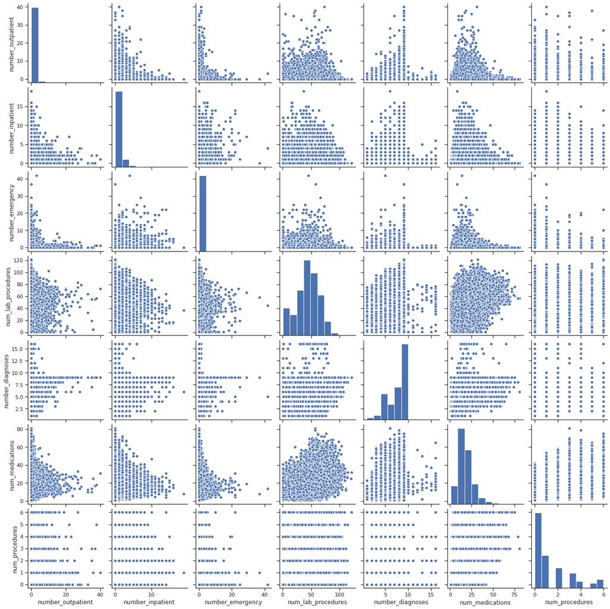

```python
sns.pairplot(df[numerical_columns])
```

Only num_lab_procedures and num_medications seem to be normaly distibuted.

#### Q2.c Cardinality

We will consider all categorical feature that have more than 100 unique values to have high cardinalty. https://www.kdnuggets.com/2016/08/include-high-cardinality-attributes-predictive-model.html

The features are listed below:

```python
df.nunique()[~df.columns.isin(['encounter_id', 'patient_nbr', 'number_outpatient', 'number_inpatient', 'number_emergency', 'num_lab_procedures', 'number_diagnoses', 'num_medications', 'num_procedures'])][df.nunique()>100]
```

```
primary_diagnosis_code      667
other_diagnosis_codes     15133
ndc_code                    250
dtype: int64
```

Considering primary_diagnosis_code and other_diagnosis_codes are using ICD9 diagnosis code that catagorisase all diagnosis codes it is naturaly a feature of high cardinalty with 667 and 15133 unique values.

Same goes for the ndc_code feature containg ndc codes of medications people have been using, with 250 unique values.

#### Q2.d Demographic distribution

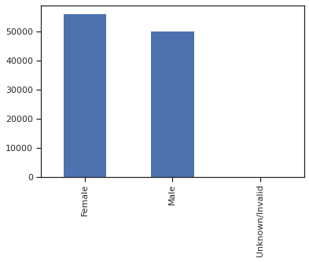

```python
df.gender.value_counts().plot.bar()
```

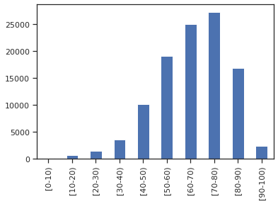

```python
df.age.value_counts().sort_values(axis = 0)[df.age.value_counts().index.sort_values()].plot.bar()
```

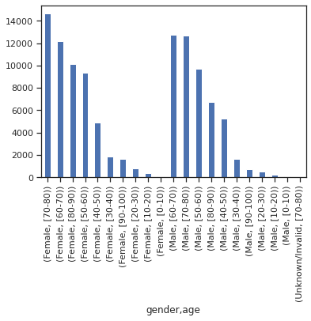

```python
df.groupby('gender')['age'].value_counts().plot.bar()
```

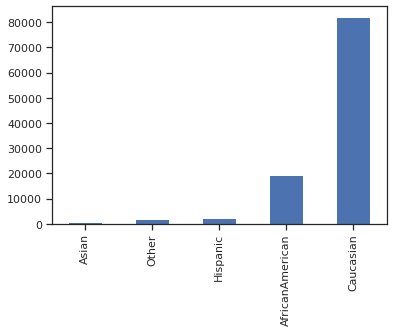

```python
df.race.value_counts().sort_values(axis = 0).plot.bar();
```

We can see form the distribution that the majority of the patients are older than fifty and are Caucasia and there are similar namber of males and female in the data.

## Reduce Dimensionality of the NDC Code Feature

**Question 3**: NDC codes are a common format to represent the wide variety of drugs that are prescribed for patient care in the United States. The challenge is that there are many codes that map to the same or similar drug. You are provided with the ndc drug lookup file https://github.com/udacity/nd320-c1-emr-data-starter/tree/master/project/data_schema_references/ndc_lookup_table.csv derived from the National Drug Codes List site(https://ndclist.com/). Please use this file to come up with a way to reduce the dimensionality of this field and create a new field in the dataset called "generic_drug_name" in the output dataframe.

```python
#NDC code lookup file
ndc_code_path = "./medication_lookup_tables/final_ndc_lookup_table"
ndc_code_df = pd.read_csv(ndc_code_path)
```

```python
ndc_code_df
```

|  | NDC_Code | Proprietary Name | Non-proprietary Name | Dosage Form | Route Name | Company Name | Product Type |
| --- | --- | --- | --- | --- | --- | --- | --- |
| 0 | 0087-6060 | Glucophage | Metformin Hydrochloride | Tablet, Film Coated | Oral | Bristol-myers Squibb Company | Human Prescription Drug |
| 1 | 0087-6063 | Glucophage XR | Metformin Hydrochloride | Tablet, Extended Release | Oral | Bristol-myers Squibb Company | Human Prescription Drug |
| 2 | 0087-6064 | Glucophage XR | Metformin Hydrochloride | Tablet, Extended Release | Oral | Bristol-myers Squibb Company | Human Prescription Drug |
| 3 | 0087-6070 | Glucophage | Metformin Hydrochloride | Tablet, Film Coated | Oral | Bristol-myers Squibb Company | Human Prescription Drug |
| 4 | 0087-6071 | Glucophage | Metformin Hydrochloride | Tablet, Film Coated | Oral | Bristol-myers Squibb Company | Human Prescription Drug |
| ... | ... | ... | ... | ... | ... | ... | ... |
| 264 | 0781-5635 | Pioglitazone Hydrochloride And Glimepiride | Pioglitazone Hydrochloride And Glimepiride | Tablet | Oral | Sandoz Inc | Human Prescription Drug |
| 265 | 64764-302 | Duetact | Pioglitazone And Glimepiride | Tablet | Oral | Takeda Pharmaceuticals America, Inc. | Human Prescription Drug |
| 266 | 64764-304 | Duetact | Pioglitazone And Glimepiride | Tablet | Oral | Takeda Pharmaceuticals America, Inc. | Human Prescription Drug |
| 267 | 66993-821 | Pioglitazone And Glimepiride | Pioglitazone And Glimepiride | Tablet | Oral | Prasco Laboratories | Human Prescription Drug |
| 268 | 66993-822 | Pioglitazone And Glimepiride | Pioglitazone And Glimepiride | Tablet | Oral | Prasco Laboratories | Human Prescription Drug |

269 rows × 7 columns

```python
ndc_code_df = ndc_code_df.rename(columns = {'NDC_Code' : 'ndc_code'})
```

```python
df.head()
```

|  | encounter_id | patient_nbr | race | gender | age | admission_type_id | discharge_disposition_id | admission_source_id | time_in_hospital | primary_diagnosis_code | other_diagnosis_codes | number_outpatient | number_inpatient | number_emergency | num_lab_procedures | number_diagnoses | num_medications | num_procedures | ndc_code | max_glu_serum | A1Cresult | change | readmitted |
| --- | --- | --- | --- | --- | --- | --- | --- | --- | --- | --- | --- | --- | --- | --- | --- | --- | --- | --- | --- | --- | --- | --- | --- |
| 1 | 149190 | 55629189 | Caucasian | Female | [10-20) | 1 | 1 | 7 | 3 | 276 | 250.01\|255 | 0 | 0 | 0 | 59 | 9 | 18 | 0 | 68071-1701 | None | None | Ch | >30 |
| 2 | 64410 | 86047875 | AfricanAmerican | Female | [20-30) | 1 | 1 | 7 | 2 | 648 | 250\|V27 | 2 | 1 | 0 | 11 | 6 | 13 | 5 | 0378-1110 | None | None | No | NO |
| 3 | 500364 | 82442376 | Caucasian | Male | [30-40) | 1 | 1 | 7 | 2 | 8 | 250.43\|403 | 0 | 0 | 0 | 44 | 7 | 16 | 1 | 68071-1701 | None | None | Ch | NO |
| 4 | 16680 | 42519267 | Caucasian | Male | [40-50) | 1 | 1 | 7 | 1 | 197 | 157\|250 | 0 | 0 | 0 | 51 | 5 | 8 | 0 | 0049-4110 | None | None | Ch | NO |
| 5 | 16680 | 42519267 | Caucasian | Male | [40-50) | 1 | 1 | 7 | 1 | 197 | 157\|250 | 0 | 0 | 0 | 51 | 5 | 8 | 0 | 68071-1701 | None | None | Ch | NO |

```python
df.ndc_code.nunique()
```

```
250
```

```python
from student_utils import reduce_dimension_ndc
```

```python
reduce_dim_df = reduce_dimension_ndc(df, ndc_code_df)
```

```python
# Number of unique values should be less for the new output field
assert df['ndc_code'].nunique() > reduce_dim_df['generic_drug_name'].nunique()
```

```python
reduce_dim_df.nunique()
```

```
encounter_id                68331
patient_nbr                 50304
race                            5
gender                          3
age                            10
admission_type_id               8
discharge_disposition_id       25
admission_source_id            17
time_in_hospital               14
primary_diagnosis_code        667
other_diagnosis_codes       15133
number_outpatient              36
number_inpatient               18
number_emergency               27
num_lab_procedures            114
number_diagnoses               16
num_medications                75
num_procedures                  7
max_glu_serum                   4
A1Cresult                       4
change                          2
readmitted                      3
generic_drug_name              21
dtype: int64
```

## Select First Encounter for each Patient

**Question 4**: In order to simplify the aggregation of data for the model, we will only select the first encounter for each patient in the dataset. This is to reduce the risk of data leakage of future patient encounters and to reduce complexity of the data transformation and modeling steps. We will assume that sorting in numerical order on the encounter_id provides the time horizon for determining which encounters come before and after another.

```python
df.groupby('patient_nbr')['encounter_id'].min().shape
```

```
(50304,)
```

```python
df.patient_nbr.nunique()
```

```
50304
```

```python
df.groupby('patient_nbr')['encounter_id'].min()
```

```
patient_nbr
135           24437208
729          189899286
774           64331490
927           14824206
1152           8380170
               ...
189349430    359725880
189365864    359719064
189445127    338462954
189481478    443811536
189502619    371459060
Name: encounter_id, Length: 50304, dtype: int64
```

```python
df[df.encounter_id == 443857166]
```

|  | encounter_id | patient_nbr | race | gender | age | admission_type_id | discharge_disposition_id | admission_source_id | time_in_hospital | primary_diagnosis_code | other_diagnosis_codes | number_outpatient | number_inpatient | number_emergency | num_lab_procedures | number_diagnoses | num_medications | num_procedures | ndc_code | max_glu_serum | A1Cresult | change | readmitted |
| --- | --- | --- | --- | --- | --- | --- | --- | --- | --- | --- | --- | --- | --- | --- | --- | --- | --- | --- | --- | --- | --- | --- | --- |
| 143420 | 443857166 | 31693671 | Caucasian | Female | [80-90) | 2 | 3 | 7 | 10 | 996 | 285\|998 | 0 | 1 | 0 | 45 | 9 | 21 | 2 | 0049-4110 | None | None | Ch | NO |
| 143421 | 443857166 | 31693671 | Caucasian | Female | [80-90) | 2 | 3 | 7 | 10 | 996 | 285\|998 | 0 | 1 | 0 | 45 | 9 | 21 | 2 | 0781-5421 | None | None | Ch | NO |
| 143422 | 443857166 | 31693671 | Caucasian | Female | [80-90) | 2 | 3 | 7 | 10 | 996 | 285\|998 | 0 | 1 | 0 | 45 | 9 | 21 | 2 | 47918-902 | None | None | Ch | NO |

```python
df.groupby('patient_nbr')['encounter_id'].min()
```

```
patient_nbr
135           24437208
729          189899286
774           64331490
927           14824206
1152           8380170
               ...
189349430    359725880
189365864    359719064
189445127    338462954
189481478    443811536
189502619    371459060
Name: encounter_id, Length: 50304, dtype: int64
```

```python
df[df.encounter_id.isin(df.groupby('patient_nbr')['encounter_id'].min())]
```

|  | encounter_id | patient_nbr | race | gender | age | admission_type_id | discharge_disposition_id | admission_source_id | time_in_hospital | primary_diagnosis_code | other_diagnosis_codes | number_outpatient | number_inpatient | number_emergency | num_lab_procedures | number_diagnoses | num_medications | num_procedures | ndc_code | max_glu_serum | A1Cresult | change | readmitted |
| --- | --- | --- | --- | --- | --- | --- | --- | --- | --- | --- | --- | --- | --- | --- | --- | --- | --- | --- | --- | --- | --- | --- | --- |
| 1 | 149190 | 55629189 | Caucasian | Female | [10-20) | 1 | 1 | 7 | 3 | 276 | 250.01\|255 | 0 | 0 | 0 | 59 | 9 | 18 | 0 | 68071-1701 | None | None | Ch | >30 |
| 2 | 64410 | 86047875 | AfricanAmerican | Female | [20-30) | 1 | 1 | 7 | 2 | 648 | 250\|V27 | 2 | 1 | 0 | 11 | 6 | 13 | 5 | 0378-1110 | None | None | No | NO |
| 3 | 500364 | 82442376 | Caucasian | Male | [30-40) | 1 | 1 | 7 | 2 | 8 | 250.43\|403 | 0 | 0 | 0 | 44 | 7 | 16 | 1 | 68071-1701 | None | None | Ch | NO |
| 4 | 16680 | 42519267 | Caucasian | Male | [40-50) | 1 | 1 | 7 | 1 | 197 | 157\|250 | 0 | 0 | 0 | 51 | 5 | 8 | 0 | 0049-4110 | None | None | Ch | NO |
| 5 | 16680 | 42519267 | Caucasian | Male | [40-50) | 1 | 1 | 7 | 1 | 197 | 157\|250 | 0 | 0 | 0 | 51 | 5 | 8 | 0 | 68071-1701 | None | None | Ch | NO |
| ... | ... | ... | ... | ... | ... | ... | ... | ... | ... | ... | ... | ... | ... | ... | ... | ... | ... | ... | ... | ... | ... | ... | ... |
| 143406 | 443842016 | 183087545 | Caucasian | Female | [70-80) | 1 | 1 | 7 | 9 | 574 | 574\|250.02 | 0 | 0 | 0 | 50 | 9 | 33 | 2 | 47918-902 | None | >7 | Ch | >30 |
| 143407 | 443842022 | 188574944 | Other | Female | [40-50) | 1 | 1 | 7 | 14 | 592 | 599\|518 | 0 | 0 | 1 | 73 | 9 | 26 | 6 | 0049-0178 | None | >8 | Ch | >30 |
| 143408 | 443842022 | 188574944 | Other | Female | [40-50) | 1 | 1 | 7 | 14 | 592 | 599\|518 | 0 | 0 | 1 | 73 | 9 | 26 | 6 | 68071-1701 | None | >8 | Ch | >30 |
| 143409 | 443842070 | 140199494 | Other | Female | [60-70) | 1 | 1 | 7 | 2 | 996 | 585\|403 | 1 | 1 | 1 | 46 | 9 | 17 | 6 | 47918-902 | None | None | No | >30 |
| 143411 | 443842340 | 120975314 | Caucasian | Female | [80-90) | 1 | 1 | 7 | 5 | 292 | 8\|304 | 0 | 0 | 1 | 76 | 9 | 22 | 1 | 47918-902 | None | None | Ch | NO |

78785 rows × 23 columns

```python
from student_utils import select_first_encounter
first_encounter_df = select_first_encounter(reduce_dim_df)
```

```python
# unique patients in transformed dataset
unique_patients = first_encounter_df['patient_nbr'].nunique()
print("Number of unique patients:{}".format(unique_patients))

# unique encounters in transformed dataset
unique_encounters = first_encounter_df['encounter_id'].nunique()
print("Number of unique encounters:{}".format(unique_encounters))

original_unique_patient_number = reduce_dim_df['patient_nbr'].nunique()
# number of unique patients should be equal to the number of unique encounters and patients in the final dataset
assert original_unique_patient_number == unique_patients
assert original_unique_patient_number == unique_encounters
print("Tests passed!!")
```

```
Number of unique patients:50304
Number of unique encounters:50304
Tests passed!!
```

## Aggregate Dataset to Right Level for Modeling

In order to provide a broad scope of the steps and to prevent students from getting stuck with data transformations, we have selected the aggregation columns and provided a function to build the dataset at the appropriate level. The 'aggregate_dataset" function that you can find in the 'utils.py' file can take the preceding dataframe with the 'generic_drug_name' field and transform the data appropriately for the project.

To make it simpler for students, we are creating dummy columns for each unique generic drug name and adding those are input features to the model. There are other options for data representation but this is out of scope for the time constraints of the course.

```python
exclusion_list = ['generic_drug_name']
grouping_field_list = [c for c in first_encounter_df.columns if c not in exclusion_list]
agg_drug_df, ndc_col_list = aggregate_dataset(first_encounter_df, grouping_field_list, 'generic_drug_name')
```

```python
assert len(agg_drug_df) == agg_drug_df['patient_nbr'].nunique() == agg_drug_df['encounter_id'].nunique()
```

## Prepare Fields and Cast Dataset

### Feature Selection

**Question 5**: After you have aggregated the dataset to the right level, we can do feature selection (we will include the ndc_col_list, dummy column features too). In the block below, please select the categorical and numerical features that you will use for the model, so that we can create a dataset subset.

For the payer_code and weight fields, please provide whether you think we should include/exclude the field in our model and give a justification/rationale for this based off of the statistics of the data. Feel free to use visualizations or summary statistics to support your choice.

```python
agg_drug_df
```

|  | encounter_id | patient_nbr | race | gender | age | admission_type_id | discharge_disposition_id | admission_source_id | time_in_hospital | primary_diagnosis_code | other_diagnosis_codes | number_outpatient | number_inpatient | number_emergency | num_lab_procedures | number_diagnoses | num_medications | num_procedures | max_glu_serum | A1Cresult | change | readmitted | generic_drug_name_array | Acarbose | Glimepiride | Glipizide | Glipizide_And_Metformin_Hcl | Glipizide_And_Metformin_Hydrochloride | Glyburide | … |
| --- | --- | --- | --- | --- | --- | --- | --- | --- | --- | --- | --- | --- | --- | --- | --- | --- | --- | --- | --- | --- | --- | --- | --- | --- | --- | --- | --- | --- | --- | --- |
| 0 | 12522 | 48330783 | Caucasian | Female | [80-90) | 2 | 1 | 4 | 13 | 398 | 427\|38 | 0 | 0 | 0 | 68 | 8 | 28 | 2 | None | None | Ch | NO | [Glipizide, Insulin Human] | 0 | 0 | 1 | 0 | 0 | 0 | … |
| 1 | 15738 | 63555939 | Caucasian | Female | [90-100) | 3 | 3 | 4 | 12 | 434 | 198\|486 | 0 | 0 | 0 | 33 | 8 | 18 | 3 | None | None | Ch | NO | [Human Insulin, Rosiglitazone Maleate] | 0 | 0 | 0 | 0 | 0 | 0 | … |
| 2 | 16680 | 42519267 | Caucasian | Male | [40-50) | 1 | 1 | 7 | 1 | 197 | 157\|250 | 0 | 0 | 0 | 51 | 5 | 8 | 0 | None | None | Ch | NO | [Human Insulin, Glipizide] | 0 | 0 | 1 | 0 | 0 | 0 | … |
| 3 | 28236 | 89869032 | AfricanAmerican | Female | [40-50) | 1 | 1 | 7 | 9 | 250.7 | 403\|996 | 0 | 0 | 0 | 47 | 9 | 17 | 2 | None | None | No | >30 | [Human Insulin] | 0 | 0 | 0 | 0 | 0 | 0 | … |
| 4 | 35754 | 82637451 | Caucasian | Male | [50-60) | 2 | 1 | 2 | 3 | 414 | 411\|250 | 0 | 0 | 0 | 31 | 9 | 16 | 6 | None | None | No | >30 | [Insulin Human] | 0 | 0 | 0 | 0 | 0 | 0 | … |
| ... | ... | ... | ... | ... | ... | ... | ... | ... | ... | ... | ... | ... | ... | ... | ... | ... | ... | ... | ... | ... | ... | ... | ... | ... | ... | ... | ... | ... | ... | … |
| 50299 | 443841992 | 184875899 | Other | Male | [40-50) | 1 | 1 | 7 | 13 | 250.8 | 730\|731 | 0 | 0 | 0 | 51 | 9 | 13 | 2 | None | None | Ch | NO | [Human Insulin, Metformin Hydrochloride] | 0 | 0 | 0 | 0 | 0 | 0 | … |
| 50300 | 443842016 | 183087545 | Caucasian | Female | [70-80) | 1 | 1 | 7 | 9 | 574 | 574\|250.02 | 0 | 0 | 0 | 50 | 9 | 33 | 2 | None | >7 | Ch | >30 | [Insulin Human, Glyburide] | 0 | 0 | 0 | 0 | 0 | 1 | … |
| 50301 | 443842022 | 188574944 | Other | Female | [40-50) | 1 | 1 | 7 | 14 | 592 | 599\|518 | 0 | 0 | 1 | 73 | 9 | 26 | 6 | None | >8 | Ch | >30 | [Human Insulin, Glipizide] | 0 | 0 | 1 | 0 | 0 | 0 | … |
| 50302 | 443842070 | 140199494 | Other | Female | [60-70) | 1 | 1 | 7 | 2 | 996 | 585\|403 | 1 | 1 | 1 | 46 | 9 | 17 | 6 | None | None | No | >30 | [Insulin Human] | 0 | 0 | 0 | 0 | 0 | 0 | … |
| 50303 | 443842340 | 120975314 | Caucasian | Female | [80-90) | 1 | 1 | 7 | 5 | 292 | 8\|304 | 0 | 0 | 1 | 76 | 9 | 22 | 1 | None | None | Ch | NO | [Insulin Human] | 0 | 0 | 0 | 0 | 0 | 0 | … |

50304 rows × 44 columns

```python
ndc_col_list
```

```
['Acarbose',
 'Glimepiride',
 'Glipizide',
 'Glipizide_And_Metformin_Hcl',
 'Glipizide_And_Metformin_Hydrochloride',
 'Glyburide',
 'Glyburide_And_Metformin_Hydrochloride',
 'Glyburide-metformin_Hydrochloride',
 'Human_Insulin',
 'Insulin_Human',
 'Metformin_Hcl',
 'Metformin_Hydrochloride',
 'Miglitol',
 'Nateglinide',
 'Pioglitazole_And_Metformin_Hydrochloride',
 'Pioglitazone',
 'Pioglitazone_Hydrochloride_And_Glimepiride',
 'Repaglinide',
 'Rosiglitazone_Maleate',
 'Tolazamide',
 'Tolbutamide']
```

```python
agg_drug_df.columns
```

```
Index(['encounter_id', 'patient_nbr', 'race', 'gender', 'age',
       'admission_type_id', 'discharge_disposition_id', 'admission_source_id',
       'time_in_hospital', 'primary_diagnosis_code', 'other_diagnosis_codes',
       'number_outpatient', 'number_inpatient', 'number_emergency',
       'num_lab_procedures', 'number_diagnoses', 'num_medications',
       'num_procedures', 'max_glu_serum', 'A1Cresult', 'change', 'readmitted',
       'generic_drug_name_array', 'Acarbose', 'Glimepiride', 'Glipizide',
       'Glipizide_And_Metformin_Hcl', 'Glipizide_And_Metformin_Hydrochloride',
       'Glyburide', 'Glyburide_And_Metformin_Hydrochloride',
       'Glyburide-metformin_Hydrochloride', 'Human_Insulin', 'Insulin_Human',
       'Metformin_Hcl', 'Metformin_Hydrochloride', 'Miglitol', 'Nateglinide',
       'Pioglitazole_And_Metformin_Hydrochloride', 'Pioglitazone',
       'Pioglitazone_Hydrochloride_And_Glimepiride', 'Repaglinide',
       'Rosiglitazone_Maleate', 'Tolazamide', 'Tolbutamide'],
      dtype='object')
```

'generic_drug_name_array' has already been one hot encoded a can be therefore removed

'encounter_id' does not provide any useful info about target variable and will be dropped

'race', 'gender', 'age' will be used for demographic analysis and as categorical features

'weight', 'payer_code', 'medical_specialty'columns have high percentage of na values and have already been dropped

'time_in_hospital' is a numerical target varriable

```python
to_drop = ['encounter_id', 'generic_drug_name_array']
```

```python
agg_drug_df = agg_drug_df.drop(to_drop, axis = 1)
```

```python
agg_drug_df
```

|  | patient_nbr | race | gender | age | admission_type_id | discharge_disposition_id | admission_source_id | time_in_hospital | primary_diagnosis_code | other_diagnosis_codes | number_outpatient | number_inpatient | number_emergency | num_lab_procedures | number_diagnoses | num_medications | num_procedures | max_glu_serum | A1Cresult | change | readmitted | Acarbose | Glimepiride | Glipizide | Glipizide_And_Metformin_Hcl | Glipizide_And_Metformin_Hydrochloride | Glyburide | Glyburide_And_Metformin_Hydrochloride | Glyburide-metformin_Hydrochloride | … |
| --- | --- | --- | --- | --- | --- | --- | --- | --- | --- | --- | --- | --- | --- | --- | --- | --- | --- | --- | --- | --- | --- | --- | --- | --- | --- | --- | --- | --- | --- | --- |
| 0 | 48330783 | Caucasian | Female | [80-90) | 2 | 1 | 4 | 13 | 398 | 427\|38 | 0 | 0 | 0 | 68 | 8 | 28 | 2 | None | None | Ch | NO | 0 | 0 | 1 | 0 | 0 | 0 | 0 | 0 | … |
| 1 | 63555939 | Caucasian | Female | [90-100) | 3 | 3 | 4 | 12 | 434 | 198\|486 | 0 | 0 | 0 | 33 | 8 | 18 | 3 | None | None | Ch | NO | 0 | 0 | 0 | 0 | 0 | 0 | 0 | 0 | … |
| 2 | 42519267 | Caucasian | Male | [40-50) | 1 | 1 | 7 | 1 | 197 | 157\|250 | 0 | 0 | 0 | 51 | 5 | 8 | 0 | None | None | Ch | NO | 0 | 0 | 1 | 0 | 0 | 0 | 0 | 0 | … |
| 3 | 89869032 | AfricanAmerican | Female | [40-50) | 1 | 1 | 7 | 9 | 250.7 | 403\|996 | 0 | 0 | 0 | 47 | 9 | 17 | 2 | None | None | No | >30 | 0 | 0 | 0 | 0 | 0 | 0 | 0 | 0 | … |
| 4 | 82637451 | Caucasian | Male | [50-60) | 2 | 1 | 2 | 3 | 414 | 411\|250 | 0 | 0 | 0 | 31 | 9 | 16 | 6 | None | None | No | >30 | 0 | 0 | 0 | 0 | 0 | 0 | 0 | 0 | … |
| ... | ... | ... | ... | ... | ... | ... | ... | ... | ... | ... | ... | ... | ... | ... | ... | ... | ... | ... | ... | ... | ... | ... | ... | ... | ... | ... | ... | ... | ... | … |
| 50299 | 184875899 | Other | Male | [40-50) | 1 | 1 | 7 | 13 | 250.8 | 730\|731 | 0 | 0 | 0 | 51 | 9 | 13 | 2 | None | None | Ch | NO | 0 | 0 | 0 | 0 | 0 | 0 | 0 | 0 | … |
| 50300 | 183087545 | Caucasian | Female | [70-80) | 1 | 1 | 7 | 9 | 574 | 574\|250.02 | 0 | 0 | 0 | 50 | 9 | 33 | 2 | None | >7 | Ch | >30 | 0 | 0 | 0 | 0 | 0 | 1 | 0 | 0 | … |
| 50301 | 188574944 | Other | Female | [40-50) | 1 | 1 | 7 | 14 | 592 | 599\|518 | 0 | 0 | 1 | 73 | 9 | 26 | 6 | None | >8 | Ch | >30 | 0 | 0 | 1 | 0 | 0 | 0 | 0 | 0 | … |
| 50302 | 140199494 | Other | Female | [60-70) | 1 | 1 | 7 | 2 | 996 | 585\|403 | 1 | 1 | 1 | 46 | 9 | 17 | 6 | None | None | No | >30 | 0 | 0 | 0 | 0 | 0 | 0 | 0 | 0 | … |
| 50303 | 120975314 | Caucasian | Female | [80-90) | 1 | 1 | 7 | 5 | 292 | 8\|304 | 0 | 0 | 1 | 76 | 9 | 22 | 1 | None | None | Ch | NO | 0 | 0 | 0 | 0 | 0 | 0 | 0 | 0 | … |

50304 rows × 42 columns

```python
numerical_columns = ['encounter_id', 'number_outpatient', 'number_inpatient', 'number_emergency', 'num_lab_procedures', 'number_diagnoses', 'num_medications', 'num_procedures']
numerical_columns
```

```
['encounter_id',
 'number_outpatient',
 'number_inpatient',
 'number_emergency',
 'num_lab_procedures',
 'number_diagnoses',
 'num_medications',
 'num_procedures']
```

```python
numerical_columns.pop(0)
```

```
'encounter_id'
```

```python
categorical_columns = []

for c in agg_drug_df.columns:
    if ((c not in numerical_columns) & (c not in ['race', 'gender', 'age']) & (c not in ['time_in_hospital', 'patient_nbr']) & (c not in ndc_col_list)):
        categorical_columns.append(c)

categorical_columns
```

```
['admission_type_id',
 'discharge_disposition_id',
 'admission_source_id',
 'primary_diagnosis_code',
 'other_diagnosis_codes',
 'max_glu_serum',
 'A1Cresult',
 'change',
 'readmitted']
```

```python
'''
Please update the list to include the features you think are appropriate for the model
and the field that we will be using to train the model. There are three required demographic features for the model
and I have inserted a list with them already in the categorical list.
These will be required for later steps when analyzing data splits and model biases.
'''
required_demo_col_list = ['race', 'gender', 'age']
student_categorical_col_list = categorical_columns + required_demo_col_list + ndc_col_list
student_numerical_col_list = numerical_columns
PREDICTOR_FIELD = 'time_in_hospital'
```

```python
def select_model_features(df, categorical_col_list, numerical_col_list, PREDICTOR_FIELD, grouping_key='patient_nbr'):
    selected_col_list = [grouping_key] + [PREDICTOR_FIELD] + categorical_col_list + numerical_col_list
    return agg_drug_df[selected_col_list]
```

```python
selected_col_list = ['patient_nbr'] + [PREDICTOR_FIELD] + student_categorical_col_list + student_numerical_col_list
```

```python
selected_features_df = select_model_features(agg_drug_df, student_categorical_col_list, student_numerical_col_list,
                                            PREDICTOR_FIELD)
```

```python
selected_features_df.head()
```

|  | patient_nbr | time_in_hospital | admission_type_id | discharge_disposition_id | admission_source_id | primary_diagnosis_code | other_diagnosis_codes | max_glu_serum | A1Cresult | change | readmitted | race | gender | age | Acarbose | Glimepiride | Glipizide | Glipizide_And_Metformin_Hcl | Glipizide_And_Metformin_Hydrochloride | Glyburide | Glyburide_And_Metformin_Hydrochloride | Glyburide-metformin_Hydrochloride | Human_Insulin | Insulin_Human | Metformin_Hcl | Metformin_Hydrochloride | Miglitol | Nateglinide | Pioglitazole_And_Metformin_Hydrochloride | … |
| --- | --- | --- | --- | --- | --- | --- | --- | --- | --- | --- | --- | --- | --- | --- | --- | --- | --- | --- | --- | --- | --- | --- | --- | --- | --- | --- | --- | --- | --- | --- |
| 0 | 48330783 | 13 | 2 | 1 | 4 | 398 | 427\|38 | None | None | Ch | NO | Caucasian | Female | [80-90) | 0 | 0 | 1 | 0 | 0 | 0 | 0 | 0 | 0 | 1 | 0 | 0 | 0 | 0 | 0 | … |
| 1 | 63555939 | 12 | 3 | 3 | 4 | 434 | 198\|486 | None | None | Ch | NO | Caucasian | Female | [90-100) | 0 | 0 | 0 | 0 | 0 | 0 | 0 | 0 | 1 | 0 | 0 | 0 | 0 | 0 | 0 | … |
| 2 | 42519267 | 1 | 1 | 1 | 7 | 197 | 157\|250 | None | None | Ch | NO | Caucasian | Male | [40-50) | 0 | 0 | 1 | 0 | 0 | 0 | 0 | 0 | 1 | 0 | 0 | 0 | 0 | 0 | 0 | … |
| 3 | 89869032 | 9 | 1 | 1 | 7 | 250.7 | 403\|996 | None | None | No | >30 | AfricanAmerican | Female | [40-50) | 0 | 0 | 0 | 0 | 0 | 0 | 0 | 0 | 1 | 0 | 0 | 0 | 0 | 0 | 0 | … |
| 4 | 82637451 | 3 | 2 | 1 | 2 | 414 | 411\|250 | None | None | No | >30 | Caucasian | Male | [50-60) | 0 | 0 | 0 | 0 | 0 | 0 | 0 | 0 | 0 | 1 | 0 | 0 | 0 | 0 | 0 | … |

### Preprocess Dataset - Casting and Imputing

We will cast and impute the dataset before splitting so that we do not have to repeat these steps across the splits in the next step. For imputing, there can be deeper analysis into which features to impute and how to impute but for the sake of time, we are taking a general strategy of imputing zero for only numerical features.

OPTIONAL: What are some potential issues with this approach? Can you recommend a better way and also implement it?

We could be imputing mean or meadian values instead or drop all nan values.

```python
processed_df = preprocess_df(selected_features_df, student_categorical_col_list,
        student_numerical_col_list, PREDICTOR_FIELD, categorical_impute_value='nan', numerical_impute_value=0)
```

## Split Dataset into Train, Validation, and Test Partitions

Please complete the function below to split the input dataset into three partitions(train, validation, test) with the following requirements.

- Approximately 60%/20%/20% train/validation/test split
- Randomly sample different patients into each data partition
- **IMPORTANT** Make sure that a patient's data is not in more than one partition, so that we can avoid possible data leakage.
- Make sure that the total number of unique patients across the splits is equal to the total number of unique patients in the original dataset
- Total number of rows in original dataset = sum of rows across all three dataset partitions

```python
processed_df['patient_nbr'].sample(frac=1)
```

```
1780     21221325
18100    11191113
27838    64113327
40247    74801736
44189    30797847
           ...
37244      905004
4767     18030015
26913    58666455
13492    12992382
33976    71452935
Name: patient_nbr, Length: 50304, dtype: int64
```

```python
patient_nbr_split = processed_df['patient_nbr'].sample(frac=1)

train_nbr = patient_nbr_split[:int(patient_nbr_split.shape[0]*0.6)]
valid_nbr = patient_nbr_split[int(patient_nbr_split.shape[0]*0.6):int(patient_nbr_split.shape[0]*0.8)]
test_nbr = patient_nbr_split[int(patient_nbr_split.shape[0]*0.8):]
```

```python
processed_df[processed_df.patient_nbr.isin(train_nbr)].shape
```

```
(30182, 42)
```

```python
from student_utils import patient_dataset_splitter
d_train, d_val, d_test = patient_dataset_splitter(processed_df, 'patient_nbr')
```

```python
d_train, d_val, d_test = patient_dataset_splitter(processed_df, 'patient_nbr')
```

```python
assert len(d_train) + len(d_val) + len(d_test) == len(processed_df)
print("Test passed for number of total rows equal!")
```

```
Test passed for number of total rows equal!
```

```python
assert (d_train['patient_nbr'].nunique() + d_val['patient_nbr'].nunique() + d_test['patient_nbr'].nunique()) == agg_drug_df['patient_nbr'].nunique()
print("Test passed for number of unique patients being equal!")
```

```
Test passed for number of unique patients being equal!
```

```python
d_train
```

|  | patient_nbr | time_in_hospital | admission_type_id | discharge_disposition_id | admission_source_id | primary_diagnosis_code | other_diagnosis_codes | max_glu_serum | A1Cresult | change | readmitted | race | gender | age | Acarbose | Glimepiride | Glipizide | Glipizide_And_Metformin_Hcl | Glipizide_And_Metformin_Hydrochloride | Glyburide | Glyburide_And_Metformin_Hydrochloride | Glyburide-metformin_Hydrochloride | Human_Insulin | Insulin_Human | Metformin_Hcl | Metformin_Hydrochloride | Miglitol | Nateglinide | Pioglitazole_And_Metformin_Hydrochloride | … |
| --- | --- | --- | --- | --- | --- | --- | --- | --- | --- | --- | --- | --- | --- | --- | --- | --- | --- | --- | --- | --- | --- | --- | --- | --- | --- | --- | --- | --- | --- | --- |
| 0 | 48330783 | 13.0 | 2 | 1 | 4 | 398 | 427\|38 | None | None | Ch | NO | Caucasian | Female | [80-90) | 0 | 0 | 1 | 0 | 0 | 0 | 0 | 0 | 0 | 1 | 0 | 0 | 0 | 0 | 0 | … |
| 1 | 63555939 | 12.0 | 3 | 3 | 4 | 434 | 198\|486 | None | None | Ch | NO | Caucasian | Female | [90-100) | 0 | 0 | 0 | 0 | 0 | 0 | 0 | 0 | 1 | 0 | 0 | 0 | 0 | 0 | 0 | … |
| 2 | 42519267 | 1.0 | 1 | 1 | 7 | 197 | 157\|250 | None | None | Ch | NO | Caucasian | Male | [40-50) | 0 | 0 | 1 | 0 | 0 | 0 | 0 | 0 | 1 | 0 | 0 | 0 | 0 | 0 | 0 | … |
| 5 | 77391171 | 7.0 | 2 | 1 | 4 | 157 | 288\|197 | None | None | Ch | <30 | AfricanAmerican | Male | [60-70) | 0 | 0 | 0 | 0 | 0 | 1 | 0 | 0 | 0 | 1 | 0 | 0 | 0 | 0 | 0 | … |
| 7 | 77586282 | 10.0 | 1 | 6 | 7 | 428 | 411\|427 | None | None | No | NO | Caucasian | Male | [80-90) | 0 | 0 | 0 | 0 | 0 | 0 | 0 | 0 | 0 | 1 | 0 | 0 | 0 | 0 | 0 | … |
| ... | ... | ... | ... | ... | ... | ... | ... | ... | ... | ... | ... | ... | ... | ... | ... | ... | ... | ... | ... | ... | ... | ... | ... | ... | ... | ... | ... | ... | ... | … |
| 50293 | 134647673 | 1.0 | 3 | 1 | 1 | 414 | 319\|272 | None | None | Ch | NO | Caucasian | Male | [40-50) | 0 | 0 | 0 | 0 | 0 | 0 | 0 | 0 | 1 | 0 | 0 | 0 | 0 | 0 | 0 | … |
| 50299 | 184875899 | 13.0 | 1 | 1 | 7 | 250.8 | 730\|731 | None | None | Ch | NO | Other | Male | [40-50) | 0 | 0 | 0 | 0 | 0 | 0 | 0 | 0 | 1 | 0 | 0 | 1 | 0 | 0 | 0 | … |
| 50300 | 183087545 | 9.0 | 1 | 1 | 7 | 574 | 574\|250.02 | None | >7 | Ch | >30 | Caucasian | Female | [70-80) | 0 | 0 | 0 | 0 | 0 | 1 | 0 | 0 | 0 | 1 | 0 | 0 | 0 | 0 | 0 | … |
| 50301 | 188574944 | 14.0 | 1 | 1 | 7 | 592 | 599\|518 | None | >8 | Ch | >30 | Other | Female | [40-50) | 0 | 0 | 1 | 0 | 0 | 0 | 0 | 0 | 1 | 0 | 0 | 0 | 0 | 0 | 0 | … |
| 50303 | 120975314 | 5.0 | 1 | 1 | 7 | 292 | 8\|304 | None | None | Ch | NO | Caucasian | Female | [80-90) | 0 | 0 | 0 | 0 | 0 | 0 | 0 | 0 | 0 | 1 | 0 | 0 | 0 | 0 | 0 | … |

30182 rows × 42 columns

## Demographic Representation Analysis of Split

After the split, we should check to see the distribution of key features/groups and make sure that there is representative samples across the partitions. The show_group_stats_viz function in the utils.py file can be used to group and visualize different groups and dataframe partitions.

### Label Distribution Across Partitions

Below you can see the distributution of the label across your splits. Are the histogram distribution shapes similar across partitions?

```
time_in_hospital
1.0     6877
2.0     8596
3.0     9042
4.0     6877
5.0     4918
6.0     3667
7.0     2880
8.0     2116
9.0     1443
10.0    1144
11.0     930
12.0     714
13.0     616
14.0     484
dtype: int64
AxesSubplot(0.125,0.125;0.775x0.755)
```

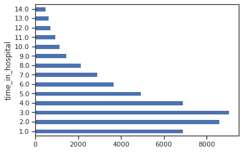

```python
show_group_stats_viz(processed_df, PREDICTOR_FIELD)
```

```
time_in_hospital
1.0     4170
2.0     5206
3.0     5312
4.0     4172
5.0     2941
6.0     2213
7.0     1680
8.0     1274
9.0      861
10.0     694
11.0     566
12.0     435
13.0     363
14.0     295
dtype: int64
AxesSubplot(0.125,0.125;0.775x0.755)
```

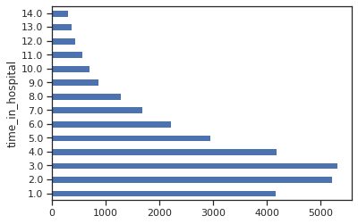

```python
show_group_stats_viz(d_train, PREDICTOR_FIELD)
```

```
time_in_hospital
1.0     1349
2.0     1694
3.0     1870
4.0     1347
5.0      965
6.0      732
7.0      631
8.0      418
9.0      281
10.0     223
11.0     192
12.0     136
13.0     130
14.0      93
dtype: int64
AxesSubplot(0.125,0.125;0.775x0.755)
```

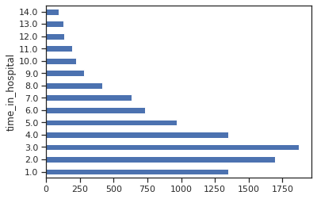

```python
show_group_stats_viz(d_test, PREDICTOR_FIELD)
```

## Demographic Group Analysis

We should check that our partitions/splits of the dataset are similar in terms of their demographic profiles. Below you can see how we might visualize and analyze the full dataset vs. the partitions.

```
gender
Female             26487
Male               23816
Unknown/Invalid        1
dtype: int64
AxesSubplot(0.125,0.125;0.775x0.755)
```

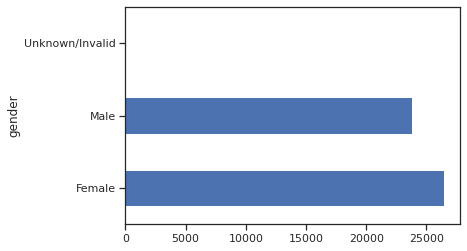

```python
# Full dataset before splitting
patient_demo_features = ['race', 'gender', 'age', 'patient_nbr']
patient_group_analysis_df = processed_df[patient_demo_features].groupby('patient_nbr').head(1).reset_index(drop=True)
show_group_stats_viz(patient_group_analysis_df, 'gender')
```

```
gender
Female             15863
Male               14318
Unknown/Invalid        1
dtype: int64
AxesSubplot(0.125,0.125;0.775x0.755)
```

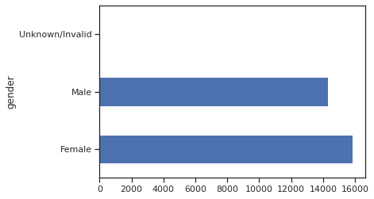

```python
# Training partition
show_group_stats_viz(d_train, 'gender')
```

```
gender
Female    5286
Male      4775
dtype: int64
AxesSubplot(0.125,0.125;0.775x0.755)
```

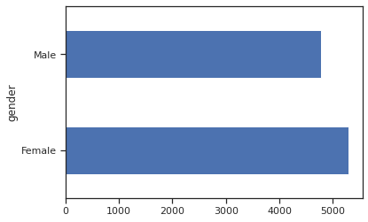

```python
# Test partition
show_group_stats_viz(d_test, 'gender')
```

## Convert Dataset Splits to TF Dataset

We have provided you the function to convert the Pandas dataframe to TF tensors using the TF Dataset API. Please note that this is not a scalable method and for larger datasets, the 'make_csv_dataset' method is recommended -https://www.tensorflow.org/api_docs/python/tf/data/experimental/make_csv_dataset.

```python
# Convert dataset from Pandas dataframes to TF dataset
batch_size = 128
diabetes_train_ds = df_to_dataset(d_train, PREDICTOR_FIELD, batch_size=batch_size)
diabetes_val_ds = df_to_dataset(d_val, PREDICTOR_FIELD, batch_size=batch_size)
diabetes_test_ds = df_to_dataset(d_test, PREDICTOR_FIELD, batch_size=batch_size)
```

```python
# We use this sample of the dataset to show transformations later
diabetes_batch = next(iter(diabetes_train_ds))[0]
def demo(feature_column, example_batch):
    #feature_layer = layers.DenseFeatures(feature_column)
    feature_layer = layers.DenseFeatures(feature_column)
    print(feature_layer(example_batch))
```

# 4. Create Categorical Features with TF Feature Columns

## Build Vocabulary for Categorical Features

Before we can create the TF categorical features, we must first create the vocab files with the unique values for a given field that are from the **training** dataset. Below we have provided a function that you can use that only requires providing the pandas train dataset partition and the list of the categorical columns in a list format. The output variable 'vocab_file_list' will be a list of the file paths that can be used in the next step for creating the categorical features.

```python
vocab_file_list = build_vocab_files(d_train, student_categorical_col_list)
```

```python
vocab_file_list
```

```
['./diabetes_vocab/admission_type_id_vocab.txt',
 './diabetes_vocab/discharge_disposition_id_vocab.txt',
 './diabetes_vocab/admission_source_id_vocab.txt',
 './diabetes_vocab/primary_diagnosis_code_vocab.txt',
 './diabetes_vocab/other_diagnosis_codes_vocab.txt',
 './diabetes_vocab/max_glu_serum_vocab.txt',
 './diabetes_vocab/A1Cresult_vocab.txt',
 './diabetes_vocab/change_vocab.txt',
 './diabetes_vocab/readmitted_vocab.txt',
 './diabetes_vocab/race_vocab.txt',
 './diabetes_vocab/gender_vocab.txt',
 './diabetes_vocab/age_vocab.txt',
 './diabetes_vocab/Acarbose_vocab.txt',
 './diabetes_vocab/Glimepiride_vocab.txt',
 './diabetes_vocab/Glipizide_vocab.txt',
 './diabetes_vocab/Glipizide_And_Metformin_Hcl_vocab.txt',
 './diabetes_vocab/Glipizide_And_Metformin_Hydrochloride_vocab.txt',
 './diabetes_vocab/Glyburide_vocab.txt',
 './diabetes_vocab/Glyburide_And_Metformin_Hydrochloride_vocab.txt',
 './diabetes_vocab/Glyburide-metformin_Hydrochloride_vocab.txt',
 './diabetes_vocab/Human_Insulin_vocab.txt',
 './diabetes_vocab/Insulin_Human_vocab.txt',
 './diabetes_vocab/Metformin_Hcl_vocab.txt',
 './diabetes_vocab/Metformin_Hydrochloride_vocab.txt',
 './diabetes_vocab/Miglitol_vocab.txt',
 './diabetes_vocab/Nateglinide_vocab.txt',
 './diabetes_vocab/Pioglitazole_And_Metformin_Hydrochloride_vocab.txt',
 './diabetes_vocab/Pioglitazone_vocab.txt',
 './diabetes_vocab/Pioglitazone_Hydrochloride_And_Glimepiride_vocab.txt',
 './diabetes_vocab/Repaglinide_vocab.txt',
 './diabetes_vocab/Rosiglitazone_Maleate_vocab.txt',
 './diabetes_vocab/Tolazamide_vocab.txt',
 './diabetes_vocab/Tolbutamide_vocab.txt']
```

## Create Categorical Features with Tensorflow Feature Column API

**Question 7**: Using the vocab file list from above that was derived fromt the features you selected earlier, please create categorical features with the Tensorflow Feature Column API, https://www.tensorflow.org/api_docs/python/tf/feature_column. Below is a function to help guide you.

```python
col = []
for j, i in enumerate(student_categorical_col_list):
    col.append(tf.feature_column.categorical_column_with_vocabulary_file(
    key = i, vocabulary_file = vocab_file_list[j], vocabulary_size=None, dtype=tf.dtypes.string,
    default_value=None, num_oov_buckets=0))
```

[output not shown]

```python
col[0]
```

```
VocabularyFileCategoricalColumn(key='admission_type_id', vocabulary_file='./diabetes_vocab/admission_type_id_vocab.txt', vocabulary_size=9, num_oov_buckets=0, dtype=tf.string, default_value=-1)
```

```python
student_categorical_col_list
```

```
['admission_type_id',
 'discharge_disposition_id',
 'admission_source_id',
 'primary_diagnosis_code',
 'other_diagnosis_codes',
 'max_glu_serum',
 'A1Cresult',
 'change',
 'readmitted',
 'race',
 'gender',
 'age',
 'Acarbose',
 'Glimepiride',
 'Glipizide',
 'Glipizide_And_Metformin_Hcl',
 'Glipizide_And_Metformin_Hydrochloride',
 'Glyburide',
 'Glyburide_And_Metformin_Hydrochloride',
 'Glyburide-metformin_Hydrochloride',
 'Human_Insulin',
 'Insulin_Human',
 'Metformin_Hcl',
 'Metformin_Hydrochloride',
 'Miglitol',
 'Nateglinide',
 'Pioglitazole_And_Metformin_Hydrochloride',
 'Pioglitazone',
 'Pioglitazone_Hydrochloride_And_Glimepiride',
 'Repaglinide',
 'Rosiglitazone_Maleate',
 'Tolazamide',
 'Tolbutamide']
```

```python
def create_tf_categorical_feature_cols(categorical_col_list,
                              vocab_dir='./diabetes_vocab/'):
    '''
    categorical_col_list: list, categorical field list that will be transformed with TF feature column
    vocab_dir: string, the path where the vocabulary text files are located
    return:
        output_tf_list: list of TF feature columns
    '''
    output_tf_list = []
    for c in categorical_col_list:
        vocab_file_path = os.path.join(vocab_dir,  c + "_vocab.txt")
        '''
        Which TF function allows you to read from a text file and create a categorical feature
        You can use a pattern like this below...
        tf_categorical_feature_column = tf.feature_column.......

        if c in ['primary_diagnosis_code', 'other_diagnosis_codes']:
            output_tf_list.append(tf.feature_column.embedding_column(tf.feature_column.indicator_column(tf.feature_column.categorical_column_with_vocabulary_file(
                                  key = c, vocabulary_file = vocab_file_path, vocabulary_size=None, dtype=tf.dtypes.string,
                                  default_value=None, num_oov_buckets=0)), 100))

        '''
        if c in ['primary_diagnosis_code', 'other_diagnosis_codes']:
            output_tf_list.append(tf.feature_column.embedding_column(tf.feature_column.categorical_column_with_vocabulary_file(
                                  key = c, vocabulary_file = vocab_file_path, vocabulary_size=None, dtype=tf.dtypes.string,
                                  default_value=None, num_oov_buckets=0), 100))
        else:
            output_tf_list.append(tf.feature_column.indicator_column(tf.feature_column.categorical_column_with_vocabulary_file(
            key = c, vocabulary_file = vocab_file_path, vocabulary_size=None, dtype=tf.dtypes.string,
            default_value=None, num_oov_buckets=0)))

    return output_tf_list
```

```python
tf_cat_col_list = create_tf_categorical_feature_cols(student_categorical_col_list)
```

[output not shown]

```python
tf_cat_col_list[0]
```

```
IndicatorColumn(categorical_column=VocabularyFileCategoricalColumn(key='admission_type_id', vocabulary_file='./diabetes_vocab/admission_type_id_vocab.txt', vocabulary_size=9, num_oov_buckets=0, dtype=tf.string, default_value=-1))
```

```python
tf_cat_col_list[3]
```

```
EmbeddingColumn(categorical_column=VocabularyFileCategoricalColumn(key='primary_diagnosis_code', vocabulary_file='./diabetes_vocab/primary_diagnosis_code_vocab.txt', vocabulary_size=607, num_oov_buckets=0, dtype=tf.string, default_value=-1), dimension=100, combiner='mean', initializer=<tensorflow.py…
```

```python
diabetes_batch
```

[output not shown]

[output cut: 531 more lines]

[output not shown]

```python
test_cat_var1 = tf_cat_col_list[0]
print("Example categorical field:\n{}".format(test_cat_var1))
demo(test_cat_var1, diabetes_batch)
```

```
Example categorical field:
IndicatorColumn(categorical_column=VocabularyFileCategoricalColumn(key='admission_type_id', vocabulary_file='./diabetes_vocab/admission_type_id_vocab.txt', vocabulary_size=9, num_oov_buckets=0, dtype=tf.string, default_value=-1))
WARNING:tensorflow:From /opt/conda/lib/python3.7/site-packages/tensorflow_core/python/feature_column/feature_column_v2.py:4267: IndicatorColumn._variable_shape (from tensorflow.python.feature_column.feature_column_v2) is deprecated and will be removed in a future version.
Instructions for updating:
The old _FeatureColumn APIs are being deprecated. Please use the new FeatureColumn APIs instead.
WARNING:tensorflow:From /opt/conda/lib/python3.7/site-packages/tensorflow_core/python/feature_column/feature_column_v2.py:4322: VocabularyFileCategoricalColumn._num_buckets (from tensorflow.python.feature_column.feature_column_v2) is deprecated and will be removed in a future version.
Instructions for updating:
The old _FeatureColumn APIs are being deprecated. Please use the new FeatureColumn APIs instead.
tf.Tensor(
[[0. 0. 1. ... 0. 0. 0.]
 [0. 1. 0. ... 0. 0. 0.]
 [0. 0. 0. ... 0. 0. 0.]
 ...
 [0. 0. 0. ... 0. 0. 0.]
 [0. 0. 1. ... 0. 0. 0.]
 [0. 1. 0. ... 0. 0. 0.]], shape=(128, 9), dtype=float32)
```

```python
test_cat_var1 = tf_cat_col_list[4]
print("Example categorical field:\n{}".format(test_cat_var1))
demo(test_cat_var1, diabetes_batch)
```

```
Example categorical field:
EmbeddingColumn(categorical_column=VocabularyFileCategoricalColumn(key='other_diagnosis_codes', vocabulary_file='./diabetes_vocab/other_diagnosis_codes_vocab.txt', vocabulary_size=9036, num_oov_buckets=0, dtype=tf.string, default_value=-1), dimension=100, combiner='mean', initializer=<tensorflow.pyt…
tf.Tensor(
[[ 0.14196941  0.03131044  0.04813251 ...  0.06765882 -0.15585063
   0.04515144]
 [-0.17232572 -0.04041914  0.06572213 ...  0.09526321  0.00819452
   0.00974482]
 [-0.03286698  0.11610787 -0.06174139 ... -0.004584   -0.06743913
  -0.14843908]
 ...
 [ 0.07181983  0.04620585  0.04188298 ...  0.13755843  0.00933678
   0.00072673]
 [ 0.12889418 -0.02398214  0.14063065 ...  0.08172968  0.05162884
   0.17530422]
 [ 0.01640023  0.0333616  -0.00041502 ... -0.10904495 -0.07839957
   0.07874467]], shape=(128, 100), dtype=float32)
```

# 5. Create Numerical Features with TF Feature Columns

**Question 8**: Using the TF Feature Column API(https://www.tensorflow.org/api_docs/python/tf/feature_column/), please create normalized Tensorflow numeric features for the model. Try to use the z-score normalizer function below to help as well as the 'calculate_stats_from_train_data' function.

```python
from student_utils import create_tf_numeric_feature
```

For simplicity the create_tf_numerical_feature_cols function below uses the same normalizer function across all features(z-score normalization) but if you have time feel free to analyze and adapt the normalizer based off the statistical distributions. You may find this as a good resource in determining which transformation fits best for the data https://developers.google.com/machine-learning/data-prep/transform/normalization.

```python
def calculate_stats_from_train_data(df, col):
    mean = df[col].describe()['mean']
    std = df[col].describe()['std']
    return mean, std

def create_tf_numerical_feature_cols(numerical_col_list, train_df):
    tf_numeric_col_list = []
    for c in numerical_col_list:
        mean, std = calculate_stats_from_train_data(train_df, c)
        print(mean, std, type(mean), type(std))
        tf_numeric_feature = create_tf_numeric_feature(c, mean, std)
        tf_numeric_col_list.append(tf_numeric_feature)
    return tf_numeric_col_list
```

```python
tf_numeric_feature = create_tf_numeric_feature('num_medications', 16.744914187263934, 8.403264850917077)
```

```python
tf_numeric_feature
```

```
NumericColumn(key='num_medications', shape=(1,), default_value=(0.0,), dtype=tf.float32, normalizer_fn=<function create_tf_numeric_feature.<locals>.<lambda> at 0x7fadc056d4d0>)
```

```python
tf_numeric_feature.normalizer_fn
```

```
<function student_utils.create_tf_numeric_feature.<locals>.<lambda>(x)>
```

```python
tf_cont_col_list = create_tf_numerical_feature_cols(student_numerical_col_list, d_train)
```

```
0.29265787555496653 1.070026724489161 <class 'numpy.float64'> <class 'numpy.float64'>
0.1906765621893844 0.6383286898392001 <class 'numpy.float64'> <class 'numpy.float64'>
0.11477039294944007 0.5826658832078039 <class 'numpy.float64'> <class 'numpy.float64'>
43.51500894572924 20.138458063024842 <class 'numpy.float64'> <class 'numpy.float64'>
7.271254390033795 1.9947766547699535 <class 'numpy.float64'> <class 'numpy.float64'>
16.612053541846134 8.516584224288 <class 'numpy.float64'> <class 'numpy.float64'>
1.4400304817440859 1.7767159679102087 <class 'numpy.float64'> <class 'numpy.float64'>
```

```python
tf_cont_col_list[0]
```

```
NumericColumn(key='number_outpatient', shape=(1,), default_value=(0.0,), dtype=tf.float32, normalizer_fn=<function create_tf_numeric_feature.<locals>.<lambda> at 0x7fadc05b8c20>)
```

```python
test_cont_var1 = tf_cont_col_list[2]
print("Example continuous field:\n{}\n".format(test_cont_var1))
demo(test_cont_var1, diabetes_batch)
```

[output not shown]

[output cut: 77 more lines]

[output not shown]

```python
tf_cont_col_list
```

```
[NumericColumn(key='number_outpatient', shape=(1,), default_value=(0.0,), dtype=tf.float32, normalizer_fn=<function create_tf_numeric_feature.<locals>.<lambda> at 0x7fadc05b8c20>),
 NumericColumn(key='number_inpatient', shape=(1,), default_value=(0.0,), dtype=tf.float32, normalizer_fn=<function create_tf_numeric_feature.<locals>.<lambda> at 0x7fadc05af9e0>),
 NumericColumn(key='number_emergency', shape=(1,), default_value=(0.0,), dtype=tf.float32, normalizer_fn=<function create_tf_numeric_feature.<locals>.<lambda> at 0x7fadc05b8dd0>),
 NumericColumn(key='num_lab_procedures', shape=(1,), default_value=(0.0,), dtype=tf.float32, normalizer_fn=<function create_tf_numeric_feature.<locals>.<lambda> at 0x7fadc056d290>),
 NumericColumn(key='number_diagnoses', shape=(1,), default_value=(0.0,), dtype=tf.float32, normalizer_fn=<function create_tf_numeric_feature.<locals>.<lambda> at 0x7fadc057e8c0>),
 NumericColumn(key='num_medications', shape=(1,), default_value=(0.0,), dtype=tf.float32, normalizer_fn=<function create_tf_numeric_feature.<locals>.<lambda> at 0x7fadc057e7a0>),
 NumericColumn(key='num_procedures', shape=(1,), default_value=(0.0,), dtype=tf.float32, normalizer_fn=<function create_tf_numeric_feature.<locals>.<lambda> at 0x7fadc057e830>)]
```

# 6. Build Deep Learning Regression Model with Sequential API and TF Probability Layers

## Use DenseFeatures to combine features for model

Now that we have prepared categorical and numerical features using Tensorflow's Feature Column API, we can combine them into a dense vector representation for the model. Below we will create this new input layer, which we will call 'claim_feature_layer'.

tf_cat_col_list = [tf.feature_column.indicator_column(i) for i in tf_cat_col_list]

```python
claim_feature_columns = tf_cat_col_list + tf_cont_col_list
claim_feature_layer = tf.keras.layers.DenseFeatures(claim_feature_columns)
```

## Build Sequential API Model from DenseFeatures and TF Probability Layers

Below we have provided some boilerplate code for building a model that connects the Sequential API, DenseFeatures, and Tensorflow Probability layers into a deep learning model. There are many opportunities to further optimize and explore different architectures through benchmarking and testing approaches in various research papers, loss and evaluation metrics, learning curves, hyperparameter tuning, TF probability layers, etc. Feel free to modify and explore as you wish.

**OPTIONAL**: Come up with a more optimal neural network architecture and hyperparameters. Share the process in discovering the architecture and hyperparameters.

```python
np.mean((d_train['time_in_hospital'] - d_train['time_in_hospital'].mean())**2)
```

```
8.867715468748973
```

```python
def build_sequential_model(feature_layer):
    model = tf.keras.Sequential([
        feature_layer,
        tf.keras.layers.Dense(30, activation='relu'),
        #tf.keras.layers.Dropout(rate = 0.5),
        tf.keras.layers.BatchNormalization(),
        tf.keras.layers.Dense(10, activation='relu'),
        #tf.keras.layers.Dropout(rate = 0.5),
        tf.keras.layers.BatchNormalization(),
        tfp.layers.DenseVariational(1+1, posterior_mean_field, prior_trainable),
        tfp.layers.DistributionLambda(
            lambda t:tfp.distributions.Normal(loc=t[..., :1],
                                             scale=1e-3 + tf.math.softplus(0.01 * t[...,1:])
                                             )
        ),
    ])
    return model

def build_diabetes_model(train_ds, val_ds,  feature_layer,  epochs=10, loss_metric='mse'):
    model = build_sequential_model(feature_layer)
    model.compile(optimizer=tf.keras.optimizers.Adam(learning_rate=0.005), loss=loss_metric, metrics=[loss_metric])
    early_stop = tf.keras.callbacks.EarlyStopping(monitor='val_loss', patience=4)
    history = model.fit(train_ds, validation_data=val_ds,
                        callbacks=[early_stop],
                        epochs=epochs)
    return model, history
```

```python
diabetes_model, history = build_diabetes_model(diabetes_train_ds, diabetes_val_ds,  claim_feature_layer,  epochs=40)
```

```
Train for 236 steps, validate for 79 steps
```

## Show Model Uncertainty Range with TF Probability

**Question 9**: Now that we have trained a model with TF Probability layers, we can extract the mean and standard deviation for each prediction. Please fill in the answer for the m and s variables below. The code for getting the predictions is provided for you below.

```python
feature_list = student_categorical_col_list + student_numerical_col_list
diabetes_x_tst = dict(d_test[feature_list])
diabetes_yhat = diabetes_model(diabetes_x_tst)
preds = diabetes_model.predict(diabetes_test_ds)
```

```python
d_test.shape
```

```
(10061, 42)
```

```python
preds.shape
```

```
(10061, 1)
```

```python
from student_utils import get_mean_std_from_preds

m, s = get_mean_std_from_preds(diabetes_yhat)
```

## Show Prediction Output

```python
prob_outputs = {
    "pred": preds.flatten(),
    "actual_value": d_test['time_in_hospital'].values,
    "pred_mean": m.numpy().flatten(),
    "pred_std": s.numpy().flatten()
}
prob_output_df = pd.DataFrame(prob_outputs)
```

```python
prob_output_df.head()
```

|  | pred | actual_value | pred_mean | pred_std |
| --- | --- | --- | --- | --- |
| 0 | 3.778042 | 9.0 | 3.457391 | 0.688704 |
| 1 | 0.676558 | 7.0 | 4.423172 | 0.687200 |
| 2 | 2.407435 | 2.0 | 3.554671 | 0.688500 |
| 3 | 4.250305 | 7.0 | 4.004317 | 0.688260 |
| 4 | 2.498268 | 9.0 | 6.762645 | 0.681961 |

```python
prob_output_df.shape
```

```
(10061, 4)
```

## Convert Regression Output to Classification Output for Patient Selection

**Question 10**: Given the output predictions, convert it to a binary label for whether the patient meets the time criteria or does not (HINT: use the mean prediction numpy array). The expected output is a numpy array with a 1 or 0 based off if the prediction meets or doesnt meet the criteria.

```python
prob_output_df['pred_mean'].isna().sum()
```

```
0
```

```python
prob_output_df['pred_mean'].shape
```

```
(10061,)
```

```python
from student_utils import get_student_binary_prediction

student_binary_prediction = get_student_binary_prediction(prob_output_df, 'pred_mean')
```

```python
student_binary_prediction.shape
```

```
(10061,)
```

### Add Binary Prediction to Test Dataframe

Using the student_binary_prediction output that is a numpy array with binary labels, we can use this to add to a dataframe to better visualize and also to prepare the data for the Aequitas toolkit. The Aequitas toolkit requires that the predictions be mapped to a binary label for the predictions (called 'score' field) and the actual value (called 'label_value').

```python
def add_pred_to_test(test_df, pred_np, demo_col_list):
    for c in demo_col_list:
        test_df.loc[:, c] = test_df[c].astype(str)
    test_df.loc[:, 'score'] = pred_np.values
    test_df.loc[:, 'label_value'] = test_df['time_in_hospital'].apply(lambda x: 1 if x >=5 else 0)
    return test_df

pred_test_df = add_pred_to_test(d_test, student_binary_prediction, ['race', 'gender'])
```

```python
pred_test_df[['patient_nbr', 'gender', 'race', 'time_in_hospital', 'score', 'label_value']].head()
```

|  | patient_nbr | gender | race | time_in_hospital | score | label_value |
| --- | --- | --- | --- | --- | --- | --- |
| 3 | 89869032 | Female | AfricanAmerican | 9.0 | 0 | 1 |
| 6 | 85504905 | Female | Caucasian | 7.0 | 0 | 1 |
| 11 | 86047875 | Female | AfricanAmerican | 2.0 | 0 | 0 |
| 30 | 101002446 | Male | Caucasian | 7.0 | 0 | 1 |
| 39 | 51838164 | Male | Caucasian | 9.0 | 1 | 1 |

## Model Evaluation Metrics

**Question 11**: Now it is time to use the newly created binary labels in the 'pred_test_df' dataframe to evaluate the model with some common classification metrics. Please create a report summary of the performance of the model and be sure to give the ROC AUC, F1 score(weighted), class precision and recall scores.

```python
from sklearn.metrics import roc_auc_score
from sklearn.metrics import precision_score
from sklearn.metrics import recall_score
from sklearn.metrics import f1_score

def evaluation_report(y_pred, y_true):
    roc_auc = roc_auc_score(y_true, y_pred)
    _precision_score = precision_score(y_true, y_pred, average='weighted')
    _recall_score = recall_score(y_true, y_pred, average='weighted')
    _f1_score = f1_score(y_true, y_pred, average='weighted')


    print('roc_auc: ', roc_auc)
    print('precision_score: ', _precision_score)
    print('recall_score: ', _recall_score)
    print('f1_score: ', _f1_score)
```

```python
evaluation_report(pred_test_df['score'], pred_test_df['label_value'])
```

```
roc_auc:  0.7113306318414608
precision_score:  0.7478394604034051
recall_score:  0.7511181791074446
f1_score:  0.7424022749564916
```

There is the fundamental trade-off between precision and recall. If our model has very high precision (when our model classifies a target class instance it is almost always right) we have low recall (we missed a lot of target class instances).

The opposite is also true. If our model has very high recall (we classified most of the target class instances), we have low precision (we also misclassified a lot of other classes).

Looking at the results of our model we can see that the precision_score and recall_score are similar and therfore our model balances the importance of these two metric.

The model could be further improved by more exhaustive search of different model architectures and ways to prevent overfitting. I have tried out batch normalization and dropout.

# 7. Evaluating Potential Model Biases with Aequitas Toolkit

## Prepare Data For Aequitas Bias Toolkit

Using the gender and race fields, we will prepare the data for the Aequitas Toolkit.

```python
# Aequitas
from aequitas.preprocessing import preprocess_input_df
from aequitas.group import Group
from aequitas.plotting import Plot
from aequitas.bias import Bias
from aequitas.fairness import Fairness

ae_subset_df = pred_test_df[['race', 'gender', 'score', 'label_value']]
ae_df, _ = preprocess_input_df(ae_subset_df)
g = Group()
xtab, _ = g.get_crosstabs(ae_df)
absolute_metrics = g.list_absolute_metrics(xtab)
clean_xtab = xtab.fillna(-1)
aqp = Plot()
b = Bias()
```

```
model_id, score_thresholds 1 {'rank_abs': [2873]}
```

```python
absolute_metrics = g.list_absolute_metrics(xtab)
xtab[[col for col in xtab.columns if col not in absolute_metrics]]
```

|  | model_id | score_threshold | k | attribute_name | attribute_value | pp | pn | fp | fn | tn | tp | group_label_pos | group_label_neg | group_size | total_entities |
| --- | --- | --- | --- | --- | --- | --- | --- | --- | --- | --- | --- | --- | --- | --- | --- |
| 0 | 1 | binary 0/1 | 2873 | race | AfricanAmerican | 511 | 1280 | 154 | 296 | 984 | 357 | 653 | 1138 | 1791 | 10061 |
| 1 | 1 | binary 0/1 | 2873 | race | Asian | 12 | 55 | 5 | 10 | 45 | 7 | 17 | 50 | 67 | 10061 |
| 2 | 1 | binary 0/1 | 2873 | race | Caucasian | 2242 | 5565 | 600 | 1356 | 4209 | 1642 | 2998 | 4809 | 7807 | 10061 |
| 3 | 1 | binary 0/1 | 2873 | race | Hispanic | 50 | 156 | 17 | 24 | 132 | 33 | 57 | 149 | 206 | 10061 |
| 4 | 1 | binary 0/1 | 2873 | race | Other | 58 | 132 | 12 | 30 | 102 | 46 | 76 | 114 | 190 | 10061 |
| 5 | 1 | binary 0/1 | 2873 | gender | Female | 1572 | 3714 | 431 | 887 | 2827 | 1141 | 2028 | 3258 | 5286 | 10061 |
| 6 | 1 | binary 0/1 | 2873 | gender | Male | 1301 | 3474 | 357 | 829 | 2645 | 944 | 1773 | 3002 | 4775 | 10061 |

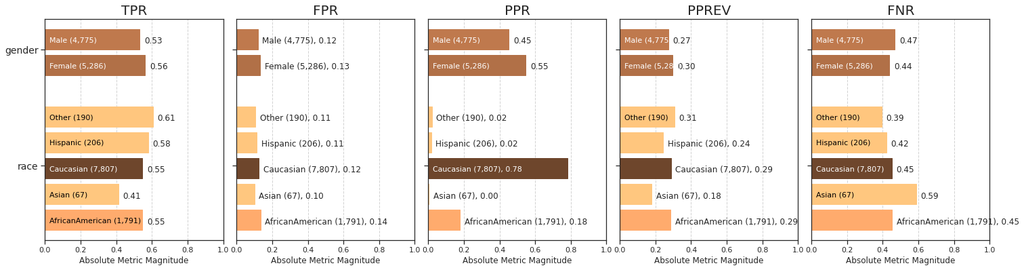

```python
p = aqp.plot_group_metric_all(xtab, metrics=['tpr', 'fpr', 'ppr', 'pprev', 'fnr'], ncols=5)
```

## Reference Group Selection

Below we have chosen the reference group for our analysis but feel free to select another one.

```python
# test reference group with Caucasian Male
bdf = b.get_disparity_predefined_groups(clean_xtab,
                    original_df=ae_df,
                    ref_groups_dict={'race':'Caucasian', 'gender':'Male'
                                     },
                    alpha=0.05,
                    check_significance=False)


f = Fairness()
fdf = f.get_group_value_fairness(bdf)
```

```
get_disparity_predefined_group()
```

## Race and Gender Bias Analysis for Patient Selection

**Question 12**: For the gender and race fields, please plot two metrics that are important for patient selection below and state whether there is a significant bias in your model across any of the groups along with justification for your statement.

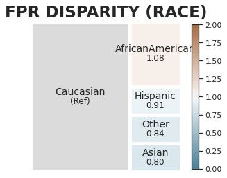

```python
# Plot two metrics

aqp.plot_disparity(bdf, group_metric='fpr_disparity', attribute_name='race')
```

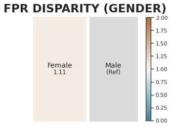

```python
aqp.plot_disparity(bdf, group_metric='fpr_disparity', attribute_name='gender')
```

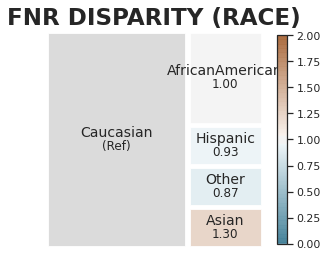

```python
aqp.plot_disparity(bdf, group_metric='fnr_disparity', attribute_name='race')
```

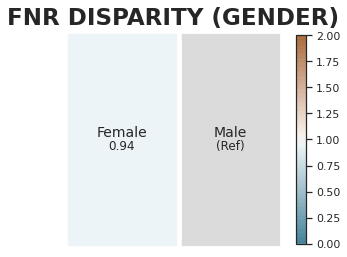

```python
aqp.plot_disparity(bdf, group_metric='fnr_disparity', attribute_name='gender')
```

Is there significant bias in your model for either race or gender?

When we look at FPR we can see that for the gender there is a small disparity for females at 1.11 while for the race the disparity is small for most groups and mild for Asians.

If on the other hand we take a look at FNR we can see that for the gender there is small disparity for females while for the race the is small disperity for all groups except for Asians.

## Fairness Analysis Example - Relative to a Reference Group

**Question 13**: Earlier we defined our reference group and then calculated disparity metrics relative to this grouping. Please provide a visualization of the fairness evaluation for this reference group and analyze whether there is disparity.

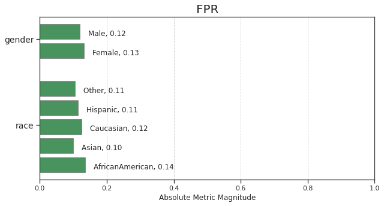

```python
# Reference group fairness plot

fpr_fairness = aqp.plot_fairness_group(fdf, group_metric='fpr', title=True)
```

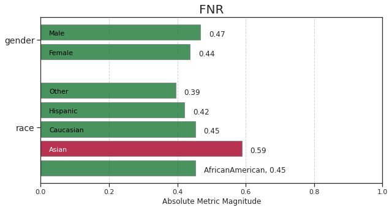

```python
fpr_fairness = aqp.plot_fairness_group(fdf, group_metric='fnr', title=True)
```